# CDC Diabetes Health Indicators

**Team Members:**

- Jason Lu (Data Engineering & Pipeline Architecture): yoja66@seas.upenn.edu
- Osvaldo Valentino Aceves (Feature Engineering & Visualization): ovaceves@seas.upenn.edu
- Peggy Che (Model Development & Evaluation): yidanche@seas.upenn.edu

## Presentation Video Link:

https://drive.google.com/file/d/1ncrHtVEt7h3D-CGwQTM3gvU_CZNT9Ub0/view?usp=sharing

# Part 1: Introduction and Background

## 1.1 Data Source

The data used in this project ultimately come from the Behavioral Risk Factor Surveillance System (BRFSS), an annual health-related telephone survey conducted by the U.S. Centers for Disease Control and Prevention (CDC). BRFSS collects state-specific data on U.S. adults' health-related risk behaviors, chronic health conditions, and use of preventive services.

Since 1984, BRFSS has expanded from 15 states to all 50 states, the District of Columbia, and several U.S. territories, completing over 400,000 adult interviews per year, which makes it the largest continuously conducted health survey system in the world. Each annual BRFSS dataset contains a few hundred variables covering topics such as tobacco use, physical activity, health care coverage, and diet, collected from one randomly selected adult per household via telephone survey.

The dataset we use is not the raw BRFSS file but a derived and partially cleaned subset based on BRFSS 2015, released on Kaggle as the “Diabetes Health Indicators” dataset. This derived dataset selects a smaller set of variables related to diabetes risk and converts the original CDC data into CSV format. In this project, we treat this Kaggle dataset as our starting point and apply additional cleaning, preprocessing, and feature engineering as part of our analysis.

## 1.2 What Is Diabetes and How Does It Affect the Body?

Diabetes is a chronic disorder of blood glucose regulation. After food is digested, carbohydrates are broken down into sugars that enter the bloodstream. Rising blood glucose levels signal the pancreas to release insulin, a hormone that helps move glucose from the blood into cells, where it is used for energy.

In diabetes, this system does not function properly. The body may not produce enough insulin or may not respond effectively to insulin (insulin resistance). As a result, glucose remains in the bloodstream instead of being taken up by cells, leading to chronically elevated blood sugar. Over time, this can damage blood vessels and nerves and affect multiple organ systems.

## 1.3 Why Diabetes Matters (Public Health Perspective)?

Diabetes is a common chronic disease in the United States and is associated with serious complications, including cardiovascular disease, kidney disease, vision loss, and lower-limb amputation. Diabetes and prediabetes affect tens of millions of Americans and impose substantial direct and indirect economic costs. A large proportion of individuals with diabetes or prediabetes are undiagnosed, which makes early risk detection and targeted prevention especially important. In this context, predictive models based on survey data can be useful tools for identifying high-risk individuals and informing public health interventions.

## 1.4 Dataset used in Final Project

For this project, we use the file "diabetes_binary_health_indicators_BRFSS2015.csv" from the Diabetes Health Indicators Dataset on Kaggle. Link: https://www.kaggle.com/datasets/alexteboul/diabetes-health-indicators-dataset

**Key characteristics:**

- **Observations:** 253,680 survey responses
- **Features:** 21 health and demographic variables
- **Target variable:** Diabetes_binary
  - 0 = no diabetes
  - 1 = prediabetes or diabetes
- **Class balance:** Imbalanced; the majority of respondents are in the 0 (no diabetes) class

This larger, imbalanced dataset more closely reflects the real population distribution of diabetes status and will require us to account for class imbalance during model evaluation and, if needed, model training.

## 1.5 Project Objectives and Value Proposition

**Objective**

The primary objective of this project is to build a binary classification model that predicts an individual's diabetes status using BRFSS health indicators:

- 0 = No diabetes
- 1 = Prediabetes or diabetes

What we will do?

- Train and evaluate several classification models (e.g., logistic regression, tree-based methods).
- Compare their performance using metrics such as accuracy, precision, recall, F1-score, and ROC-AUC.
- Analyze model outputs (e.g., coefficients, feature importance) to identify the most influential health and lifestyle risk factors associated with prediabetes/diabetes.

We also aim to explore feature reduction, assessing whether a smaller subset of variables can achieve similar predictive performance.

**Value Proposition**

Identifying individuals in the Prediabetes/Diabetes (Class 1) group early is crucial for prevention and disease management. Our model has the following potential value:

- It relies on accessible survey data (self-reported health and behavior indicators), which can be collected at relatively low cost.
- By supporting targeted, preventative care, such models can help reduce the long-term clinical and economic burden of diabetes at the population level.

In summary, this project not only evaluates predictive performance, but also examines how survey-based models can support practical, early-stage diabetes risk screening.

# Part 2: Data Loading & Preparation

## 2.1 Overview of the Dataset

This dataset provides survey responses from 253,680 individuals with 21 predictor features that capture demographics, lifestyle behaviors, and health conditions. Our goal is to predict diabetes status based on these accessible health indicators. The columns are as follows:

**Target Variable:**

- **Diabetes_binary** – Diabetes diagnosis status (0 = no diabetes, 1 = prediabetes or diabetes)

**Health Conditions (5 features):**

- **HighBP** – High blood pressure diagnosis (0 = no, 1 = yes)
- **HighChol** – High cholesterol diagnosis (0 = no, 1 = yes)
- **BMI** – Body Mass Index (continuous, range 12-98)
- **Stroke** – History of stroke (0 = no, 1 = yes)
- **HeartDiseaseorAttack** – History of coronary heart disease or myocardial infarction (0 = no, 1 = yes)

**Health Behaviors (5 features):**

- **Smoker** – Has smoked at least 100 cigarettes in lifetime (0 = no, 1 = yes)
- **PhysActivity** – Physical activity in past 30 days, not including job (0 = no, 1 = yes)
- **Fruits** – Consume fruit 1 or more times per day (0 = no, 1 = yes)
- **Veggies** – Consume vegetables 1 or more times per day (0 = no, 1 = yes)
- **HvyAlcoholConsump** – Heavy alcohol consumption: adult men >14 drinks/week, adult women >7 drinks/week (0 = no, 1 = yes)

**Healthcare Access (3 features):**

- **CholCheck** – Cholesterol check within past 5 years (0 = no, 1 = yes)
- **AnyHealthcare** – Has any kind of healthcare coverage (0 = no, 1 = yes)
- **NoDocbcCost** – Was there a time in past 12 months when needed to see doctor but could not because of cost? (0 = no, 1 = yes)

**Health Status (4 features):**

- **GenHlth** – General health rating (1 = excellent, 2 = very good, 3 = good, 4 = fair, 5 = poor)
- **MentHlth** – Number of days during past 30 days when mental health was not good (0-30 days)
- **PhysHlth** – Number of days during past 30 days when physical health was not good (0-30 days)
- **DiffWalk** – Serious difficulty walking or climbing stairs (0 = no, 1 = yes)

**Demographics (4 features):**

- **Sex** – Biological sex (0 = female, 1 = male)
- **Age** – 13-level age category (1 = 18-24, 2 = 25-29, 3 = 30-34, ..., 13 = 80 or older)
- **Education** – Education level (1 = never attended school or only kindergarten, 2 = grades 1-8, 3 = grades 9-11, 4 = grade 12 or GED, 5 = college 1-3 years, 6 = college 4+ years)
- **Income** – Income scale (1 = less than \$10000, 2 = \$10000-\$15000, 3 = \$15000-\$20000, 4 = \$20000-\$25000, 5 = \$25000-\$35000, 6 = \$35000-\$50000, 7 = \$50000-\$75000, 8 = \$75000 or more)

## 2.2 Data Loading

```python
# Run this cell to mount your drive (you will be prompted to sign in)
from google.colab import drive
drive.mount('/content/drive')
# Install the Kaggle API
!pip install kaggle
# Create the kaggle directory
# (NOTE: Do NOT run this cell more than once unless restarting kernel)
!mkdir ~/.kaggle
# Read the uploaded kaggle.json file
!cp /content/drive/MyDrive/kaggle.json ~/.kaggle/
# Download the diabetes dataset
!kaggle datasets download -d alexteboul/diabetes-health-indicators-dataset
# Unzip the dataset
!unzip diabetes-health-indicators-dataset.zip
```

```
Dataset URL: https://www.kaggle.com/datasets/alexteboul/diabetes-health-indicators-dataset
License(s): CC0-1.0
Downloading diabetes-health-indicators-dataset.zip to /content
  0% 0.00/6.03M [00:00<?, ?B/s]
100% 6.03M/6.03M [00:00<00:00, 319MB/s]
Archive:  diabetes-health-indicators-dataset.zip
  inflating: diabetes_012_health_indicators_BRFSS2015.csv
  inflating: diabetes_binary_5050split_health_indicators_BRFSS2015.csv
  inflating: diabetes_binary_health_indicators_BRFSS2015.csv
```

```python
# Import and install necessary libraries
import numpy as np
import pandas as pd
import seaborn as sns
import matplotlib.pyplot as plt
from sklearn.linear_model import LogisticRegression
from sklearn.model_selection import train_test_split, GridSearchCV, StratifiedKFold
from sklearn.metrics import accuracy_score, precision_score, recall_score, f1_score, roc_curve, auc
from sklearn.preprocessing import OneHotEncoder, OrdinalEncoder, StandardScaler
from sklearn.ensemble import RandomForestClassifier, GradientBoostingClassifier
from sklearn.tree import DecisionTreeClassifier
from sklearn.decomposition import PCA
import random
import math
import datetime as dt
from xgboost import XGBClassifier
import os
from scipy import stats
from scipy.stats import chi2_contingency
from imblearn.over_sampling import SMOTE

# Settings
pd.set_option('display.max_columns', None)
pd.set_option('display.precision', 2)
```

```python
# Load the dataset
# Using the full binary dataset as per our project proposal
df = pd.read_csv('diabetes_binary_health_indicators_BRFSS2015.csv')
```

```python
# Display the shape of the dataframe
df.shape
```

```
(253680, 22)
```

```python
# Display first five rows
df.head()
```

|  | Diabetes_binary | HighBP | HighChol | CholCheck | BMI | Smoker | Stroke | HeartDiseaseorAttack | PhysActivity | Fruits | Veggies | HvyAlcoholConsump | AnyHealthcare | NoDocbcCost | GenHlth | MentHlth | PhysHlth | DiffWalk | Sex | Age | Education | Income |
| --- | --- | --- | --- | --- | --- | --- | --- | --- | --- | --- | --- | --- | --- | --- | --- | --- | --- | --- | --- | --- | --- | --- |
| 0 | 0.0 | 1.0 | 1.0 | 1.0 | 40.0 | 1.0 | 0.0 | 0.0 | 0.0 | 0.0 | 1.0 | 0.0 | 1.0 | 0.0 | 5.0 | 18.0 | 15.0 | 1.0 | 0.0 | 9.0 | 4.0 | 3.0 |
| 1 | 0.0 | 0.0 | 0.0 | 0.0 | 25.0 | 1.0 | 0.0 | 0.0 | 1.0 | 0.0 | 0.0 | 0.0 | 0.0 | 1.0 | 3.0 | 0.0 | 0.0 | 0.0 | 0.0 | 7.0 | 6.0 | 1.0 |
| 2 | 0.0 | 1.0 | 1.0 | 1.0 | 28.0 | 0.0 | 0.0 | 0.0 | 0.0 | 1.0 | 0.0 | 0.0 | 1.0 | 1.0 | 5.0 | 30.0 | 30.0 | 1.0 | 0.0 | 9.0 | 4.0 | 8.0 |
| 3 | 0.0 | 1.0 | 0.0 | 1.0 | 27.0 | 0.0 | 0.0 | 0.0 | 1.0 | 1.0 | 1.0 | 0.0 | 1.0 | 0.0 | 2.0 | 0.0 | 0.0 | 0.0 | 0.0 | 11.0 | 3.0 | 6.0 |
| 4 | 0.0 | 1.0 | 1.0 | 1.0 | 24.0 | 0.0 | 0.0 | 0.0 | 1.0 | 1.0 | 1.0 | 0.0 | 1.0 | 0.0 | 2.0 | 3.0 | 0.0 | 0.0 | 0.0 | 11.0 | 5.0 | 4.0 |

## 2.3 Data Quality Assessment

### 2.3.1 Basic Dataset Information

```python
# Display basic information about the dataset
df.info()
```

```
<class 'pandas.core.frame.DataFrame'>
RangeIndex: 253680 entries, 0 to 253679
Data columns (total 22 columns):
 #   Column                Non-Null Count   Dtype
---  ------                --------------   -----
 0   Diabetes_binary       253680 non-null  float64
 1   HighBP                253680 non-null  float64
 2   HighChol              253680 non-null  float64
 3   CholCheck             253680 non-null  float64
 4   BMI                   253680 non-null  float64
 5   Smoker                253680 non-null  float64
 6   Stroke                253680 non-null  float64
 7   HeartDiseaseorAttack  253680 non-null  float64
 8   PhysActivity          253680 non-null  float64
 9   Fruits                253680 non-null  float64
 10  Veggies               253680 non-null  float64
 11  HvyAlcoholConsump     253680 non-null  float64
 12  AnyHealthcare         253680 non-null  float64
 13  NoDocbcCost           253680 non-null  float64
 14  GenHlth               253680 non-null  float64
 15  MentHlth              253680 non-null  float64
 16  PhysHlth              253680 non-null  float64
 17  DiffWalk              253680 non-null  float64
 18  Sex                   253680 non-null  float64
 19  Age                   253680 non-null  float64
 20  Education             253680 non-null  float64
 21  Income                253680 non-null  float64
dtypes: float64(22)
memory usage: 42.6 MB
```

```python
df.columns.tolist()
```

```
['Diabetes_binary',
 'HighBP',
 'HighChol',
 'CholCheck',
 'BMI',
 'Smoker',
 'Stroke',
 'HeartDiseaseorAttack',
 'PhysActivity',
 'Fruits',
 'Veggies',
 'HvyAlcoholConsump',
 'AnyHealthcare',
 'NoDocbcCost',
 'GenHlth',
 'MentHlth',
 'PhysHlth',
 'DiffWalk',
 'Sex',
 'Age',
 'Education',
 'Income']
```

### 2.3.2 Missing Values Analysis

```python
# Check for missing values per column
missing_counts = df.isnull().sum().sort_values(ascending=False)
missing_percentages = (df.isnull().sum() / len(df)) * 100

missing_df = pd.DataFrame({
    'Missing Count': missing_counts,
    'Percentage': missing_percentages
})

missing_df
```

|  | Missing Count | Percentage |
| --- | --- | --- |
| Diabetes_binary | 0 | 0.0 |
| HighBP | 0 | 0.0 |
| HighChol | 0 | 0.0 |
| CholCheck | 0 | 0.0 |
| BMI | 0 | 0.0 |
| Smoker | 0 | 0.0 |
| Stroke | 0 | 0.0 |
| HeartDiseaseorAttack | 0 | 0.0 |
| PhysActivity | 0 | 0.0 |
| Fruits | 0 | 0.0 |
| Veggies | 0 | 0.0 |
| HvyAlcoholConsump | 0 | 0.0 |
| AnyHealthcare | 0 | 0.0 |
| NoDocbcCost | 0 | 0.0 |
| GenHlth | 0 | 0.0 |
| MentHlth | 0 | 0.0 |
| PhysHlth | 0 | 0.0 |
| DiffWalk | 0 | 0.0 |
| Sex | 0 | 0.0 |
| Age | 0 | 0.0 |
| Education | 0 | 0.0 |
| Income | 0 | 0.0 |

We confirm that all 22 columns have zero missing values, which means no imputation or missing-data handling is required for this dataset. This is a significant advantage for our modeling pipeline, as we can proceed directly to feature engineering without concerns about bias introduced by imputation methods.

### 2.3.3 Duplicate Row Check

```python
# Check for duplicate rows
duplicates = df.duplicated().sum()
print("Number of duplicate rows:", duplicates)
```

```
Number of duplicate rows: 24206
```

Though we have some duplicates rows, we will retain all rows because in survey data, duplicates rows often represent multiple respondents with identical answers (common profiles like "healthy 30-year-old"), not data entry errors.

### 2.3.4 Descriptive Statistics

```python
# Descriptive statistics
df.describe()
```

|  | Diabetes_binary | HighBP | HighChol | CholCheck | BMI | Smoker | Stroke | HeartDiseaseorAttack | PhysActivity | Fruits | Veggies | HvyAlcoholConsump | AnyHealthcare | NoDocbcCost | GenHlth | MentHlth | PhysHlth | DiffWalk | Sex | Age | Education | Income |
| --- | --- | --- | --- | --- | --- | --- | --- | --- | --- | --- | --- | --- | --- | --- | --- | --- | --- | --- | --- | --- | --- | --- |
| count | 253680.00 | 253680.00 | 253680.00 | 253680.00 | 253680.00 | 253680.00 | 253680.00 | 253680.00 | 253680.00 | 253680.00 | 253680.00 | 253680.00 | 253680.00 | 253680.00 | 253680.00 | 253680.00 | 253680.00 | 253680.00 | 253680.00 | 253680.00 | 253680.00 | 253680.00 |
| mean | 0.14 | 0.43 | 0.42 | 0.96 | 28.38 | 0.44 | 0.04 | 0.09 | 0.76 | 0.63 | 0.81 | 0.06 | 0.95 | 0.08 | 2.51 | 3.18 | 4.24 | 0.17 | 0.44 | 8.03 | 5.05 | 6.05 |
| std | 0.35 | 0.49 | 0.49 | 0.19 | 6.61 | 0.50 | 0.20 | 0.29 | 0.43 | 0.48 | 0.39 | 0.23 | 0.22 | 0.28 | 1.07 | 7.41 | 8.72 | 0.37 | 0.50 | 3.05 | 0.99 | 2.07 |
| min | 0.00 | 0.00 | 0.00 | 0.00 | 12.00 | 0.00 | 0.00 | 0.00 | 0.00 | 0.00 | 0.00 | 0.00 | 0.00 | 0.00 | 1.00 | 0.00 | 0.00 | 0.00 | 0.00 | 1.00 | 1.00 | 1.00 |
| 25% | 0.00 | 0.00 | 0.00 | 1.00 | 24.00 | 0.00 | 0.00 | 0.00 | 1.00 | 0.00 | 1.00 | 0.00 | 1.00 | 0.00 | 2.00 | 0.00 | 0.00 | 0.00 | 0.00 | 6.00 | 4.00 | 5.00 |
| 50% | 0.00 | 0.00 | 0.00 | 1.00 | 27.00 | 0.00 | 0.00 | 0.00 | 1.00 | 1.00 | 1.00 | 0.00 | 1.00 | 0.00 | 2.00 | 0.00 | 0.00 | 0.00 | 0.00 | 8.00 | 5.00 | 7.00 |
| 75% | 0.00 | 1.00 | 1.00 | 1.00 | 31.00 | 1.00 | 0.00 | 0.00 | 1.00 | 1.00 | 1.00 | 0.00 | 1.00 | 0.00 | 3.00 | 2.00 | 3.00 | 0.00 | 1.00 | 10.00 | 6.00 | 8.00 |
| max | 1.00 | 1.00 | 1.00 | 1.00 | 98.00 | 1.00 | 1.00 | 1.00 | 1.00 | 1.00 | 1.00 | 1.00 | 1.00 | 1.00 | 5.00 | 30.00 | 30.00 | 1.00 | 1.00 | 13.00 | 6.00 | 8.00 |

The descriptive statistics reveal several important characteristics of our dataset.

1. The target variable Diabetes_binary has a mean of 0.14, confirming the severe class imbalance with only 14% of respondents having diabetes or prediabetes.
2. BMI has a median of 27 and mean of 28.38, indicating the sample is slightly overweight on average with right-skewed distribution (75th percentile at 31).
3. The MentHlth and PhysHlth variables show means of 3.18 and 4.24 days respectively, but with medians of 0, indicating these are heavily right-skewed distributions where most respondents report zero days of poor health but a subset reports significant health issues (up to 30 days).
4. The Age variable has a mean of 8.03, corresponding to approximately the 55-59 age bracket, suggesting our sample skews toward middle-aged and older adults.
5. Education and Income both show high means (5.05 and 6.05 respectively), indicating our sample is relatively well-educated and higher-income compared to the general population.

## 2.4 Applying Course Topics: PandaSQL, DuckDB, and Regex

### 2.4.1 PandaSQL: SQL Queries on DataFrames

PandaSQL allows us to write SQL queries directly on pandas DataFrames. This is useful for complex aggregations and filtering that may be more intuitive in SQL syntax.

```python
# Install and import PandaSQL
!pip install -q pandasql
import pandasql as ps

# Query 1: Calculate diabetes prevalence by age group using SQL
query_age = '''
    SELECT
        Age,
        COUNT(*) as total_count,
        SUM(Diabetes_binary) as diabetes_count,
        ROUND(AVG(Diabetes_binary) * 100, 2) as diabetes_rate_pct
    FROM df
    GROUP BY Age
    ORDER BY Age
'''

diabetes_by_age = ps.sqldf(query_age, locals())
print("Diabetes Prevalence by Age Group (PandaSQL Query):\n")
print(diabetes_by_age)
```

```
  Preparing metadata (setup.py) ... done
Diabetes Prevalence by Age Group (PandaSQL Query):

     Age  total_count  diabetes_count  diabetes_rate_pct
0    1.0         5700            78.0               1.37
1    2.0         7598           140.0               1.84
2    3.0        11123           314.0               2.82
3    4.0        13823           626.0               4.53
4    5.0        16157          1051.0               6.50
5    6.0        19819          1742.0               8.79
6    7.0        26314          3088.0              11.74
7    8.0        30832          4263.0              13.83
8    9.0        33244          5733.0              17.25
9   10.0        32194          6558.0              20.37
10  11.0        23533          5141.0              21.85
11  12.0        15980          3403.0              21.30
12  13.0        17363          3209.0              18.48
```

The PandaSQL query reveals a clear relationship between age and diabetes prevalence. In the youngest age group **(Age category 1, representing 18-24 year olds)**, the diabetes rate is only **1.37%**, with just 78 individuals affected out of 5,700 respondents. This rate increases progressively through the age categories, reaching its peak in **age category 11 (representing 70-74 year olds)** at **21.85%**. Interestingly, the rate slightly decreases to **18-21%** in the oldest age group. This may reflect "survivor bias" - individuals with severe diabetes may have shorter life expectancy, leaving a healthier surviving population in the oldest age categories.

Thus, age should be a strong predictor, but we should be cautious about assuming a purely linear relationship. The non-monotonic pattern in the oldest groups suggests the relationship may plateau or slightly reverse.

```python
# Query 2: Identify high-risk patient profiles using SQL
query_risk = '''
    SELECT
        CASE WHEN Diabetes_binary = 1 THEN 'Diabetic' ELSE 'Non-Diabetic' END as Status,
        COUNT(*) as patient_count,
        ROUND(AVG(BMI), 2) as avg_bmi,
        ROUND(AVG(GenHlth), 2) as avg_health_rating,
        ROUND(AVG(Age), 1) as avg_age_group
    FROM df
    WHERE HighBP = 1 AND HighChol = 1
    GROUP BY Diabetes_binary
'''

high_risk_profiles = ps.sqldf(query_risk, locals())
print("\nHigh-Risk Patient Profiles (HighBP + HighChol Comorbidity):\n")
print(high_risk_profiles)
```

```
High-Risk Patient Profiles (HighBP + HighChol Comorbidity):

         Status  patient_count  avg_bmi  avg_health_rating  avg_age_group
0  Non-Diabetic          45447    29.14               2.82            9.5
1      Diabetic          19213    32.43               3.42            9.6
```

Examining patients who have both high blood pressure and high cholesterol (a known high-risk profile for metabolic syndrome), we observe notable differences between diabetic and non-diabetic individuals. Among this high-risk group, **diabetic patients have a substantially higher average BMI of 32.43 compared to 29.14 for non-diabetic patients**. Additionally, diabetic patients in this group report **worse general health, with an average rating of 3.42 versus 2.82** for non-diabetics **(where 1 is Excellent and 5 is Poor)**.

### 2.4.2 DuckDB: High-Performance Analytical SQL Engine

DuckDB is an embedded analytical database optimized for OLAP workloads. It offers superior performance for analytical queries compared to traditional approaches and integrates seamlessly with pandas.

```python
# Install and setup DuckDB
!pip install -q duckdb
import duckdb

# Register DataFrame with DuckDB
con = duckdb.connect()
con.register('diabetes_df', df)

# Complex aggregation: Health indicators analysis by general health status
query_duckdb = '''
    SELECT
        GenHlth as Health_Rating,
        CASE GenHlth
            WHEN 1 THEN 'Excellent'
            WHEN 2 THEN 'Very Good'
            WHEN 3 THEN 'Good'
            WHEN 4 THEN 'Fair'
            WHEN 5 THEN 'Poor'
        END as Health_Description,
        COUNT(*) as total_patients,
        ROUND(AVG(Diabetes_binary) * 100, 2) as diabetes_pct,
        ROUND(AVG(BMI), 2) as avg_bmi,
        ROUND(AVG(PhysHlth), 2) as avg_poor_phys_days,
        ROUND(AVG(MentHlth), 2) as avg_poor_mental_days
    FROM diabetes_df
    GROUP BY GenHlth
    ORDER BY GenHlth
'''
health_analysis = con.execute(query_duckdb).fetchdf()
print("Health Status Analysis by Self-Reported General Health (DuckDB):\n")
print(health_analysis)
```

```
Health Status Analysis by Self-Reported General Health (DuckDB):

   Health_Rating Health_Description  total_patients  diabetes_pct  avg_bmi  \
0            1.0          Excellent           45299          2.52    25.77
1            2.0          Very Good           89084          7.16    27.64
2            3.0               Good           75646         17.79    29.51
3            4.0               Fair           31570         31.01    30.69
4            5.0               Poor           12081         37.89    30.57

   avg_poor_phys_days  avg_poor_mental_days
0                0.86                  1.26
1                1.53                  1.89
2                3.39                  3.07
3               11.39                  6.55
4               23.52                 11.88
```

The DuckDB query demonstrates a striking dose-response relationship between self-reported general health and diabetes prevalence. Individuals who rate their health as **"Excellent" have a diabetes rate of only 2.52%**, while those reporting **"Poor" health have a rate of 37.89%**, representing approximately a 15-fold increase in diabetes prevalence. The **average BMI** also increases monotonically from **25.77 in the Excellent group to 30.69 in the Fair group**, though it slightly decreases to 30.57 in the Poor group. Perhaps most notably, **the number of days with poor physical health** shows a dramatic **increase from less than 1 day on average for those in Excellent health to over 23 days for those in Poor health**.

These findings validate GenHlth as one of the most important predictors in our dataset and suggest that self-reported health status captures real underlying health conditions.

```python
# DuckDB: Socioeconomic factors analysis
query_socio = '''
    SELECT
        Income,
        ROUND(AVG(Diabetes_binary) * 100, 2) as diabetes_rate,
        COUNT(*) as sample_size,
        ROUND(AVG(BMI), 2) as avg_bmi
    FROM diabetes_df
    GROUP BY Income
    ORDER BY Income
'''
income_analysis = con.execute(query_socio).fetchdf()
print("\nDiabetes Rate by Income Level (DuckDB):")
print(income_analysis)
```

```
Diabetes Rate by Income Level (DuckDB):
   Income  diabetes_rate  sample_size  avg_bmi
0     1.0          24.29         9811    29.70
1     2.0          26.19        11783    29.76
2     3.0          22.31        15994    29.22
3     4.0          20.13        20135    28.95
4     5.0          17.40        25883    28.75
5     6.0          14.51        36470    28.63
6     7.0          12.18        43219    28.41
7     8.0           7.96        90385    27.57
```

The socioeconomic analysis reveals a clear inverse relationship between income level and diabetes prevalence. **At the lowest income level (less than \$10,000 annually), the diabetes rate is 24.29%**, while **at the highest income level (\$75,000 or more), the rate drops to just 7.96%**. This represents a threefold difference in diabetes risk based on income alone. The pattern is not strictly monotonic, as income level 2 (\$10,000-\$15,000) shows the highest rate at 26.19%, but the overall trend strongly supports the conclusion that socioeconomic factors play a significant role in diabetes risk. **Average BMI also shows a slight decrease with increasing income, from 29.70 at the lowest level to 27.57 at the highest**. These findings align with public health research indicating that lower-income populations often face barriers to healthy food access, preventive healthcare, and opportunities for physical activity.

### 2.4.3 Regex: Data Validation and Pattern Matching

Regular Expressions (Regex) are essential for data validation, cleaning, and pattern extraction. We demonstrate their use for column validation and feature categorization.

```python
import re

# Validate column naming conventions
column_pattern = r'^[A-Za-z][A-Za-z0-9_]*$'  # Alphanumeric, starts with letter
valid_columns = [col for col in df.columns if re.match(column_pattern, col)]
invalid_columns = [col for col in df.columns if not re.match(column_pattern, col)]

print("Column Name Validation Using Regex")
print(f"Pattern: {column_pattern}")
print(f"Valid columns: {len(valid_columns)}/{len(df.columns)}")
print(f"Invalid columns: {invalid_columns if invalid_columns else 'None - All columns valid!'}")
```

```
Column Name Validation Using Regex
Pattern: ^[A-Za-z][A-Za-z0-9_]*$
Valid columns: 22/22
Invalid columns: None - All columns valid!
```

```python
# Use regex to categorize features by naming patterns
binary_indicator_pattern = r'^(High|Any|Hvy|No|Diff|Chol)'
health_metric_pattern = r'(Hlth|Health|BMI)'
demographic_pattern = r'^(Age|Sex|Education|Income)$'

binary_features_regex = [col for col in df.columns if re.match(binary_indicator_pattern, col)]
health_features_regex = [col for col in df.columns if re.search(health_metric_pattern, col)]
demo_features_regex = [col for col in df.columns if re.match(demographic_pattern, col)]

print("\nFeature Categorization Using Regex Patterns:")
print(f"Binary indicator features:")
print(f"  {binary_features_regex}")
print(f"Health metric features:")
print(f"  {health_features_regex}")
print(f"Demographic features:")
print(f"  {demo_features_regex}")
```

```
Feature Categorization Using Regex Patterns:
Binary indicator features:
  ['HighBP', 'HighChol', 'CholCheck', 'HvyAlcoholConsump', 'AnyHealthcare', 'NoDocbcCost', 'DiffWalk']
Health metric features:
  ['BMI', 'AnyHealthcare', 'GenHlth', 'MentHlth', 'PhysHlth']
Demographic features:
  ['Sex', 'Age', 'Education', 'Income']
```

```python
# Regex validation: Check BMI values are numeric and in valid range
def validate_bmi(bmi_value):
    """Validate BMI is a reasonable numeric value (10-100)"""
    bmi_str = str(int(bmi_value))
    # Pattern: 2-digit number between 10-99, or exactly 100
    pattern = r'^([1-9][0-9]|100)$'
    return bool(re.match(pattern, bmi_str))

bmi_valid_count = df['BMI'].apply(validate_bmi).sum()
print(f"\nBMI Validation (Regex pattern for range 10-100):")
print(f"Valid BMI values: {bmi_valid_count:,}/{len(df):,} ({bmi_valid_count/len(df)*100:.2f}%)")
print("All BMI values fall within medically plausible range.")
```

```
BMI Validation (Regex pattern for range 10-100):
Valid BMI values: 253,680/253,680 (100.00%)
All BMI values fall within medically plausible range.
```

The regex-based data validation and feature categorization demonstrates the utility of pattern matching in data preprocessing workflows. Our column name validation confirms that all 22 variables in the dataset follow proper naming conventions (starting with a letter, containing only alphanumeric characters and underscores), which is essential for compatibility with SQL queries and various analytical tools.

The feature categorization using regex patterns successfully identified **7 binary indicator features** (those beginning with "High," "Any," "Hvy," "No," "Diff," or "Chol"), **5 health-related features** (containing "Hlth," "Health," or "BMI"), and **4 demographic features** (Sex, Age, Education, Income). Finally, the BMI validation using a regex pattern confirms that 100% of BMI values fall within the medically plausible range of 10-100, indicating no data entry errors or extreme outliers that would require correction.

# Part 3: Exploratory Data Analysis (EDA)

## 3.1 Target Variable Analysis

The class distribution is the most critical aspect to understand before modeling. Let's analyze it in detail.

```python
# Calculate class distribution
target_counts = df['Diabetes_binary'].value_counts().sort_index()
target_percentages = (target_counts / len(df)) * 100

# Calculate imbalance ratio
imbalance_ratio = target_counts[0.0] / target_counts[1.0]

print("Class Distribution:")
print(f"No Diabetes(0): {target_counts[0.0]:,} ({target_percentages[0.0]:.1f}%)")
print(f"Prediabetes/Diabetes(1): {target_counts[1.0]:,} ({target_percentages[1.0]:.1f}%)")
print(f"Imbalance Ratio: {imbalance_ratio:.2f}:1")
```

```
Class Distribution:
No Diabetes(0): 218,334 (86.1%)
Prediabetes/Diabetes(1): 35,346 (13.9%)
Imbalance Ratio: 6.18:1
```

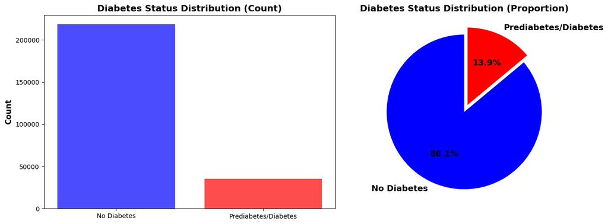

```python
# Visualization
fig, axes = plt.subplots(1, 2, figsize=(14, 5))

# Bar plot
axes[0].bar(['No Diabetes', 'Prediabetes/Diabetes'], target_counts.values, color=['blue', 'red'], alpha=0.7)
axes[0].set_ylabel('Count', fontsize=12, fontweight='bold')
axes[0].set_title('Diabetes Status Distribution (Count)', fontsize=14, fontweight='bold')

# Pie chart
axes[1].pie(target_counts.values, labels=['No Diabetes', 'Prediabetes/Diabetes'],
           autopct='%1.1f%%', startangle=90, colors=['blue', 'red'], explode=(0, 0.1),
           textprops={'fontsize': 13, 'fontweight': 'bold'})
axes[1].set_title('Diabetes Status Distribution (Proportion)', fontsize=14, fontweight='bold')

plt.tight_layout()
plt.show()
```

We find that the severe 6.18:1 imbalance means we cannot use accuracy as our primary metric. A model that always predicts "No Diabetes" would achieve 86% accuracy but be useless.

## 3.2 Feature Categorization

```python
# Check unique values for each column
# Help identify categorical vs continuous
unique_counts = df.nunique().sort_values()
unique_counts
```

|  | 0 |
| --- | --- |
| Diabetes_binary | 2 |
| HighBP | 2 |
| HighChol | 2 |
| CholCheck | 2 |
| Smoker | 2 |
| Stroke | 2 |
| HeartDiseaseorAttack | 2 |
| PhysActivity | 2 |
| AnyHealthcare | 2 |
| Fruits | 2 |
| Veggies | 2 |
| HvyAlcoholConsump | 2 |
| NoDocbcCost | 2 |
| DiffWalk | 2 |
| Sex | 2 |
| GenHlth | 5 |
| Education | 6 |
| Income | 8 |
| Age | 13 |
| MentHlth | 31 |
| PhysHlth | 31 |
| BMI | 84 |

**dtype:** int64

```python
binary_features = ['HighBP', 'HighChol', 'CholCheck', 'Smoker', 'Stroke',
                   'HeartDiseaseorAttack', 'PhysActivity', 'AnyHealthcare', 'Fruits', 'Veggies',
                   'HvyAlcoholConsump', 'NoDocbcCost', 'DiffWalk', 'Sex']

ordinal_features = ['GenHlth', 'Education', 'Income', 'Age']

continuous_features = ['BMI', 'MentHlth', 'PhysHlth']

TARGET = 'Diabetes_binary'
```

## 3.3 Feature Relationships with Target Variable

### 3.3.1 Binary Features vs Diabetes

#### **Prevalence Comparison (Proportions)**

- **Goal:** To compare the prevalence rate (percentage of occurrence) of various health conditions between Non-Diabetic and Diabetic groups.
- **Method:** We group the data by Diabetes_binary and calculate the mean of the binary features.
- **Statistical Note:** For binary data (0/1), the mean is mathematically equivalent to the proportion of positive cases.
- **Insight:** This table allows us to quantify exactly how much more common conditions like High Blood Pressure or Cholesterol are among diabetic patients compared to the healthy population.

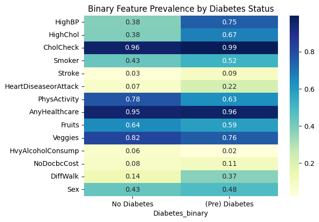

```python
# Group by target class and calculate the mean (proportion) for each binary feature
prev = df.groupby("Diabetes_binary")[binary_features].mean().T\
    .rename(columns={0:"No Diabetes", 1:"(Pre) Diabetes"})

# Plot heatmap to visualize
sns.heatmap(prev, annot=True, cmap="YlGnBu", fmt=".2f")
plt.title("Binary Feature Prevalence by Diabetes Status")
plt.show()
```

#### **Odds Ratios Analysis**

- **Goal:** To quantify the strength of the association between binary lifestyle/health factors and Diabetes.
- **Method:** We calculate the odds of having diabetes for individuals with a specific condition versus those without it. An odds ration of 1 means there is no association. A ratio greater than 1 signifies a positive association, where the exposure increases the odds of the outcome, while a ratio less than 1 indicates a negative association, where the exposure decreases the odds.
- **Why this is important:** In medical datasets, correlation can be vague. The Odds Ratio is interpretable: an OR > 1 (to the right of the red line) indicates a Risk Factor, while an OR < 1 indicates a Protective Factor.
- **Insight:** Features like HighBP and GenHlth (bad health) likely show high ORs, indicating they drastically increase the odds of being diabetic.

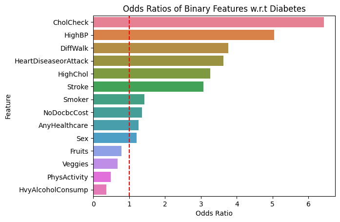

```python
# Calculate Odds Ratios for binary features
def odds_ratio(feature):
    ct = pd.crosstab(df[feature], df["Diabetes_binary"])
    ct = ct + 0.00001
    o_r = (ct.loc[1,1] / ct.loc[1,0]) / (ct.loc[0,1] / ct.loc[0,0])
    return o_r

odds_ratios = {feature: odds_ratio(feature) for feature in binary_features}
odds_ratios = pd.Series(odds_ratios).sort_values(ascending=False)

# Plotting
sns.barplot(x=odds_ratios.values, y=odds_ratios.index, hue = odds_ratios.index)
plt.title("Odds Ratios of Binary Features w.r.t Diabetes")
plt.xlabel("Odds Ratio")
plt.ylabel("Feature")
plt.axvline(1, color='red', linestyle='--')
plt.show()
```

### 3.3.2 Ordinal Features vs Diabetes

#### **Ordinal Features: Prevalence Trends**

- **Goal:** To observe how the probability of having diabetes changes across ordered categories.
- **Method:** We calculate the mean of the target variable Diabetes_binary for each category. Since the target is 0 or 1, the mean represents the prevalence proportion (e.g., 0.2 = 20% risk).
- **Insight:** We expect to see clear gradients. For example, as GenHlth scores increase (1=Excellent, 5=Poor), the proportion of diabetes should rise sharply, indicating a strong positive correlation.

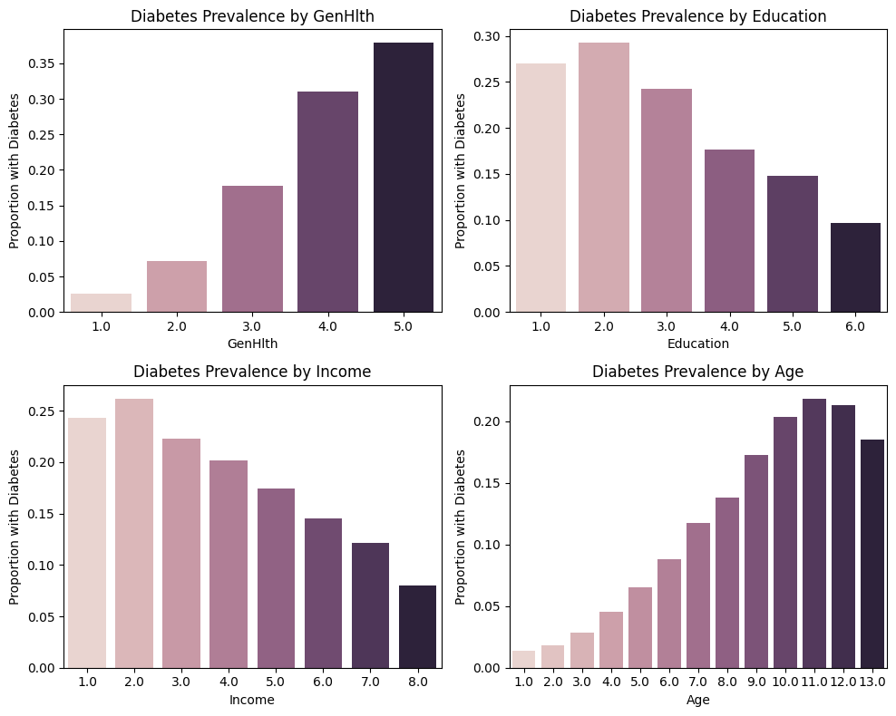

```python
plt.figure(figsize=(10, 8))

# Loop through ordinal features to create side-by-side plots
for i, col in enumerate(ordinal_features, 1):
    plt.subplot(2, 2, i)
    prop = df.groupby(col)["Diabetes_binary"].mean()
    sns.barplot(x=prop.index, y=prop.values, hue=prop.index, legend=False)
    plt.title(f"Diabetes Prevalence by {col}")
    plt.xlabel(col)
    plt.ylabel("Proportion with Diabetes")

plt.tight_layout()
plt.show()
```

#### **Cumulative Distribution Plot (CDF) Analysis**

- **Goal:** To determine if the diabetic population systematically scores higher or lower on ordinal scales compared to the non-diabetic population.
- **Method:** We use the Empirical Cumulative Distribution Function (ECDF).

Unlike histograms, CDFs allow us to clearly see Stochastic Dominance. If the "Diabetes" curve is shifted to the right (e.g., for GenHlth), it means diabetics consistently have poorer health scores. If the curve is shifted to the left (e.g., for Income or Education), it implies diabetics tend to have lower socioeconomic status.

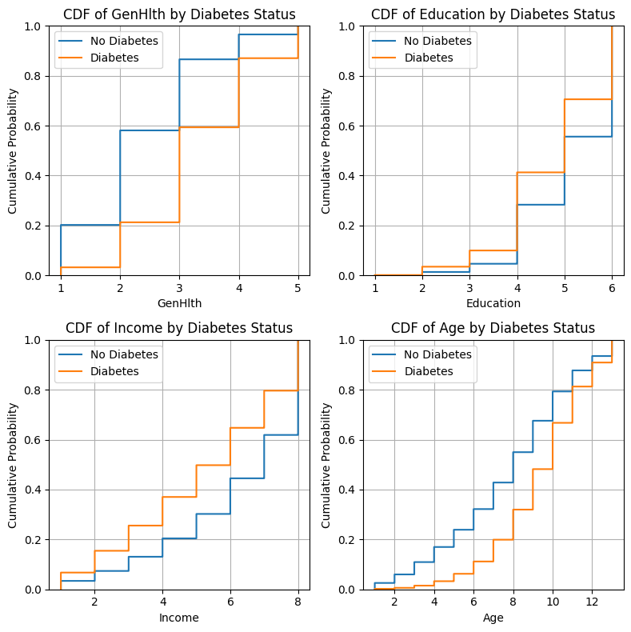

```python
plt.figure(figsize=(8,8))
for i, col in enumerate(ordinal_features, 1):
    plt.subplot(2, 2, i)

    # Plot ECDF for Non-Diabetics (Class 0) vs Diabetics (Class 1)
    # Visualize the "gap" or shift between the two populations
    sns.ecdfplot(data=df[df["Diabetes_binary"] == 0], x=col, label="No Diabetes")
    sns.ecdfplot(data=df[df["Diabetes_binary"] == 1], x=col, label="Diabetes")

    plt.title(f"CDF of {col} by Diabetes Status")
    plt.grid(True)
    plt.xlabel(col)
    plt.ylabel("Cumulative Probability")
    plt.legend()

plt.tight_layout()
plt.show()
```

### 3.3.3 Continuous Features vs Diabetes

#### **Violin Plots**

- **Goal:** To compare the density and spread of continuous variables (MentHlth, PhysHlth, BMI) between the two groups.
- **Method:** We use Violin Plots, which combine a boxplot with a kernel density estimation (KDE). This is superior to simple boxplots when we want to see the "shape" of the data distribution.
- **Insight:**
  - **Concentration at 0:** For MentHlth and PhysHlth, both groups are concentrated at 0, but it can still be useful to see the difference in "cone shape" of the distributions.
  - **The "Tail" Difference:** However, the Diabetic group (1) has a much "thicker" tail extending towards 30 days. This indicates that while many diabetics report good health, a significant sub-population suffers from chronic issues (30 days of poor health), whereas the non-diabetic distribution tapers off much faster.

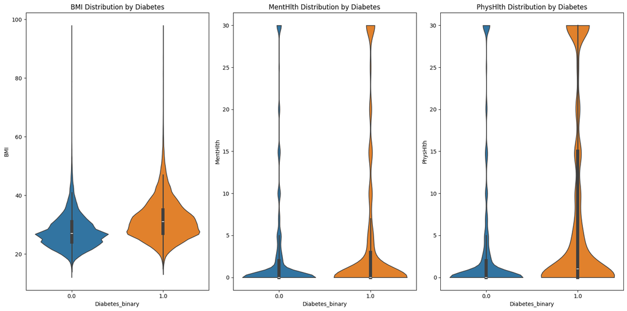

```python
plt.figure(figsize=(16,8))
for i, col in enumerate(continuous_features, 1):
    plt.subplot(1, 3, i)

    # Violin plot visualizes the probability density of the data at different values
    # cut=0: limits the plot to the actual data range
    sns.violinplot(data=df, x="Diabetes_binary", y=col,
                   cut=0, hue = "Diabetes_binary", legend = False)
    plt.title(f"{col} Distribution by Diabetes")
plt.tight_layout()
plt.show()
```

## 3.4 Multivariate Analysis

### 3.4.1 Correlation Matrix

**Goal:** To visualize the linear relationships between all 21 variables simultaneously and identify potential multicollinearity, we calculate the Pearson Correlation Coefficient (ranging from -1 to +1) for every pair of features and map it to a color gradient.

**Multicollinearity:** We observe strong correlations between certain features, such as PhysHlth and GenHlth. This suggests these variables might provide duplicate information, which we may need to address during Feature Engineering.

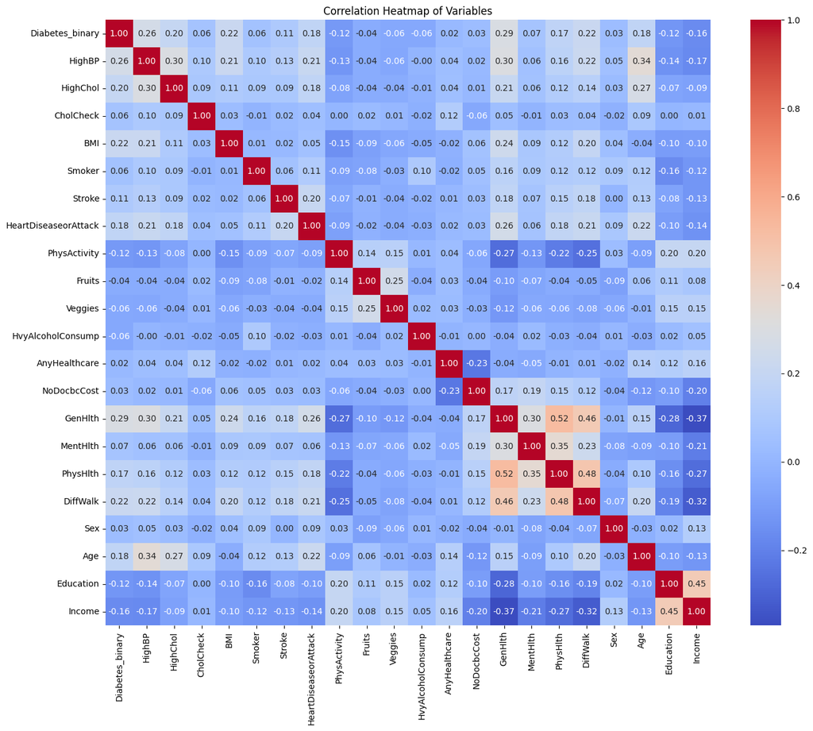

```python
corr_matrix = df.corr()

plt.figure(figsize=(15, 12))
sns.heatmap(corr_matrix,
    annot=True,          # show correlation values
    fmt=".2f",           # round to 2 decimals
    cmap="coolwarm",     # color palette
    cbar=True,           # include color bar
    square=True
)
plt.title('Correlation Heatmap of Variables')
plt.tight_layout()
plt.show()
```

### 3.4.2 Interaction EDA: Age vs Income

**Method:** We generate two heatmaps

- Co-occurrence Matrix: Shows the raw count of respondents in each Age-Income bucket (to check for sample bias).
- Prevalence Heatmap: Shows the percentage of diabetics in each bucket.

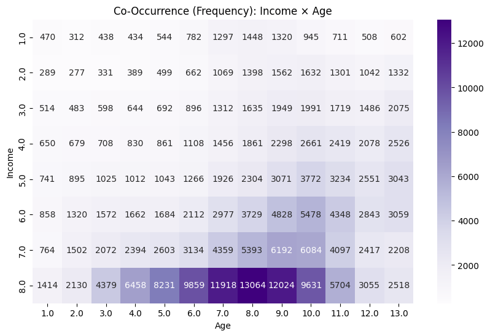

```python
feature1 = "Income"
feature2 = "Age"
# Crosstab counts the number of observations for every combination of Income and Age
cooc = pd.crosstab(df[feature1],df[feature2])

plt.figure(figsize=(10, 6))
sns.heatmap(cooc, cmap="Purples", annot=True, fmt="d")
plt.title(f"Co-Occurrence (Frequency): {feature1} × {feature2}")
plt.xlabel(feature2)
plt.ylabel(feature1)
plt.show()
```

**Sample Skew:** The dataset is heavily skewed towards wealthier patients(Income level 8), particularly in the 50-69 age range (Age categories 7-10).

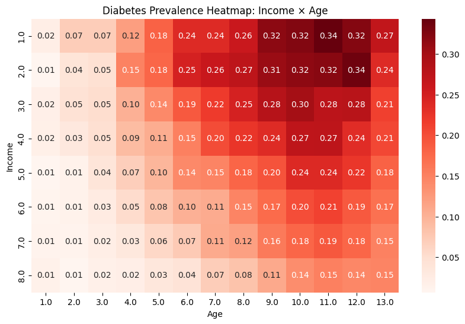

```python
# Group by both features, calculate mean (prevalence), and unstack to create a matrix format
rate = df.groupby([feature1, feature2])["Diabetes_binary"].mean().unstack()

plt.figure(figsize=(10, 6))
sns.heatmap(rate, cmap="Reds", annot=True, fmt=".2f")
plt.title(f"Diabetes Prevalence Heatmap: {feature1} × {feature2}")
plt.xlabel(feature2)
plt.ylabel(feature1)
plt.show()
```

**The Risk "Hotspot":** Despite having fewer data points, the highest prevalence of diabetes (darkest red) is concentrated in the lowest income groups (Income 1-2) among the elderly (Age 10-13). This suggests that low socioeconomic status significantly exacerbates age-related diabetes risk.

## 3.5 Key Takeaways from EDA

Based on our exploratory analysis, we have identified four critical findings that will guide our modeling strategy:

1. **Severe Class Imbalance:**
   - The dataset is heavily skewed, with only **~14%** of respondents having diabetes.
   - *Implication:* We cannot rely on simple accuracy. We must handle the class imbalance by using **SMOTE** or **Class Weights** methods.
2. **Top Predictors:**
   - **General Health (`GenHlth`)**, **High Blood Pressure (`HighBP`)**, and **BMI** show the strongest correlation with diabetes.
   - *Implication:* These features will likely drive our model's decisions.
3. **Socioeconomic Interaction:**
   - Diabetes prevalence is not randomly distributed; it is highest among **low-income** and **less-educated** individuals, particularly in older age groups.
   - *Implication:* Socioeconomic status acts as a significant risk multiplier.
4. **Multicollinearity:**
   - Strong correlations exist between features like `PhysHlth` (Physical Health) and `GenHlth` (General Health).
   - *Implication:* We may need to perform **Feature Selection** to remove redundant variables and prevent model instability.

These EDA findings directly inform our modeling strategy: we will focus on GenHlth, HighBP, BMI, and Age as key predictors while retaining all 21 features to capture the full signal in the data.

# Part 4: Data Preprocessing & Feature Engineering

Before feeding data into machine learning models, we must prepare it. This involves splitting the data, scaling continuous variables so they don't dominate the model, and addressing the severe class imbalance (86% No Diabetes vs. 14% Diabetes) identified in our EDA.

## 4.1 Train-Test Split

- **Method:** We use train_test_split with the stratify parameter.
- **Goal:** Separate the data into a training set and a testing set.

```python
# Separate features and target
X = df.drop('Diabetes_binary', axis=1)
y = df['Diabetes_binary']

# Train-test split with stratification (maintains class distribution)
X_train, X_test, y_train, y_test = train_test_split(X, y, test_size=0.2, random_state=42, stratify=y)

print(f"Training set: {X_train.shape}")
print(f"Test set: {X_test.shape}\n")

# Check the class distribution in training set
y_train.value_counts(normalize=True)
```

```
Training set: (202944, 21)
Test set: (50736, 21)
```

| Diabetes_binary | proportion |
| --- | --- |
| 0.0 | 0.86 |
| 1.0 | 0.14 |

**dtype:** float64

## 4.2 Outlier Handling

**Method:** We focus our outlier detection on continuous variables: `BMI`, `MentHlth`, and `PhysHlth`. Binary and ordinal features are categorical by definition and do not require outlier removal. We use the **Interquartile Range (IQR)** method to identify extreme values.

```python
continuous_cols = ['BMI', 'MentHlth', 'PhysHlth']

# Loop through each continuous feature to calculate outliers using IQR
for col in continuous_cols:
    Q1 = df[col].quantile(0.25)
    Q3 = df[col].quantile(0.75)
    IQR = Q3 - Q1

    # Define bounds and count outliers
    lower_bound = Q1 - 1.5 * IQR
    upper_bound = Q3 + 1.5 * IQR

    outliers = df[(df[col] < lower_bound) | (df[col] > upper_bound)]
    num_outliers = outliers.shape[0]
    percentage = (num_outliers / df.shape[0]) * 100

    print(f"Feature '{col}':")
    print(f"  - IQR Bounds: {lower_bound:.2f} to {upper_bound:.2f}")
    print(f"  - Outliers Found: {num_outliers} ({percentage:.2f}%)")

    # Specific check for BMI
    if col == 'BMI':
        max_bmi = df['BMI'].max()
        print(f"  - Max BMI in dataset: {max_bmi} (Medically possible, retained)")

    print("-" * 30)
```

```
Feature 'BMI':
  - IQR Bounds: 13.50 to 41.50
  - Outliers Found: 9847 (3.88%)
  - Max BMI in dataset: 98.0 (Medically possible, retained)
------------------------------
Feature 'MentHlth':
  - IQR Bounds: -3.00 to 5.00
  - Outliers Found: 36208 (14.27%)
------------------------------
Feature 'PhysHlth':
  - IQR Bounds: -4.50 to 7.50
  - Outliers Found: 40949 (16.14%)
------------------------------
```

**1. Observations:**

- **BMI (3.88% Outliers):**
  - We identified **9,847 outliers** (approx. 3.9%) with BMI values exceeding the statistical upper bound of 41.5.
  - The maximum observed BMI is **98.0**. While extreme, this falls within the medically documented range for super-morbid obesity, a critical risk factor for diabetes.
- **Mental & Physical Health (~15% Outliers):**
  - A significant portion of the dataset was flagged as outliers: **14.27% for Mental Health** and **16.14% for Physical Health**.
  - This high percentage is due to the data distribution being heavily skewed towards 0 (as seen in our Violin plots). The "outliers" are simply individuals who reported 5+ days of poor health, which represents a valid and important sub-population rather than noise.

**2. Decision: RETAIN ALL**

- **Reasoning:**
  - **Signal vs. Noise:** In medical analytics, extreme values often carry the strongest predictive signal. A BMI of 98 or reporting 30 days of poor physical health are strong indicators of chronic conditions.
  - **Data Integrity:** Removing ~16% of our data (the PhysHlth outliers) would strip the dataset of its most vulnerable patients, severely biasing the model towards "healthy" cases and reducing its sensitivity.
- **Conclusion:** To ensure our model to detect high-risk patients, we will **retain all identified outliers** and proceed with the full dataset.

## 4.3 Feature Scaling (Standardization)

- **Method:** We use StandardScaler to transform continuous features (BMI, MentHlth, PhysHlth) to have a mean of 0 and a standard deviation of 1.
- **Goal:** Normalize the range of continuous variables so they are comparable to binary (0/1) variables.
- **Why this is good:** Models like Logistic Regression and SVM calculate "distances" between data points. If BMI ranges from 12-98 and HighBP is only 0-1, the model will irrationally think BMI is 100x more important just because the number is bigger. Scaling prevents this bias.

```python
from sklearn.preprocessing import StandardScaler

# Define ONLY continuous features for the main preprocessing pipeline
# We leave Ordinal features (Age, Income, etc.) untouched to preserve their structure
cols_to_scale = ['BMI', 'MentHlth', 'PhysHlth']

# Initialize scaler
scaler = StandardScaler()

# Fit on training data and transform both train and test
X_train[cols_to_scale] = scaler.fit_transform(X_train[cols_to_scale])
X_test[cols_to_scale] = scaler.transform(X_test[cols_to_scale])

# Display head to confirm: BMI is scaled (decimal), but Age is still an integer (e.g., 9.0)
X_train.head()
```

|  | HighBP | HighChol | CholCheck | BMI | Smoker | Stroke | HeartDiseaseorAttack | PhysActivity | Fruits | Veggies | HvyAlcoholConsump | AnyHealthcare | NoDocbcCost | GenHlth | MentHlth | PhysHlth | DiffWalk | Sex | Age | Education | Income |
| --- | --- | --- | --- | --- | --- | --- | --- | --- | --- | --- | --- | --- | --- | --- | --- | --- | --- | --- | --- | --- | --- |
| 153147 | 0.0 | 0.0 | 1.0 | -0.06 | 1.0 | 0.0 | 0.0 | 1.0 | 1.0 | 1.0 | 0.0 | 1.0 | 0.0 | 2.0 | -0.43 | -0.49 | 0.0 | 1.0 | 2.0 | 4.0 | 5.0 |
| 176137 | 1.0 | 0.0 | 1.0 | -0.82 | 1.0 | 0.0 | 0.0 | 1.0 | 1.0 | 1.0 | 0.0 | 1.0 | 0.0 | 2.0 | -0.43 | -0.49 | 0.0 | 1.0 | 13.0 | 4.0 | 7.0 |
| 175578 | 1.0 | 1.0 | 1.0 | 0.09 | 0.0 | 0.0 | 0.0 | 1.0 | 1.0 | 1.0 | 0.0 | 1.0 | 0.0 | 1.0 | -0.43 | -0.49 | 0.0 | 1.0 | 9.0 | 6.0 | 8.0 |
| 177887 | 1.0 | 1.0 | 1.0 | 1.61 | 0.0 | 0.0 | 0.0 | 0.0 | 0.0 | 0.0 | 0.0 | 1.0 | 0.0 | 4.0 | -0.43 | -0.49 | 0.0 | 1.0 | 7.0 | 4.0 | 7.0 |
| 182143 | 0.0 | 1.0 | 1.0 | -1.88 | 1.0 | 0.0 | 0.0 | 1.0 | 1.0 | 1.0 | 0.0 | 1.0 | 1.0 | 5.0 | 3.61 | 2.95 | 1.0 | 0.0 | 7.0 | 5.0 | 1.0 |

## 4.4 Feature Selection

Our goal is to reduce multicollinearity and improve model efficiency. We explored two methods to reduce dimensionality and address multicollinearity:

1. **Principal Component Analysis (PCA):** A mathematical transformation approach.
2. **Correlation-Based Selection:** A medical interpretability approach.

### 4.4.1 Method A: Principal Component Analysis (PCA)

**Method:** We applied PCA to our preprocessed training data (`X_train`) to determine if the dataset could be efficiently compressed. Since the continuous features are already standardized in Section 4.3, we can directly analyze the variance.

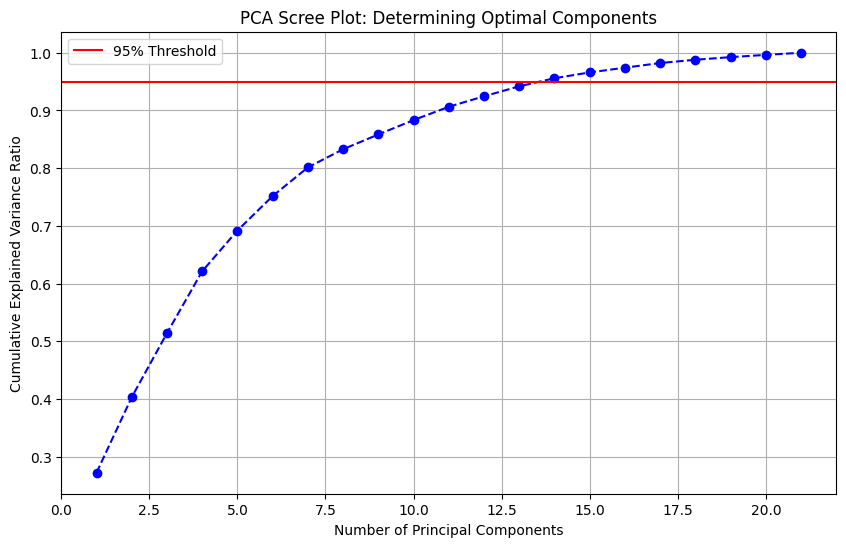

```
PCA Experiment Result: If we were to use PCA, we would need 14 components to capture 95% variance.
```

```python
from sklearn.decomposition import PCA
import matplotlib.pyplot as plt

# Step 1: Create a temporary fully-scaled dataset for PCA
# We need to scale Age, Income, etc. JUST for PCA, otherwise PCA is biased
ordinal_features = ['Age', 'Income', 'Education', 'GenHlth']
X_train_pca_temp = X_train.copy()

# Apply scaling to the ordinal features in the temp dataset
temp_scaler = StandardScaler()
X_train_pca_temp[ordinal_features] = temp_scaler.fit_transform(X_train_pca_temp[ordinal_features])

# Step 2: Fit PCA on this fully scaled data
pca = PCA(n_components=None)
pca.fit(X_train_pca_temp)

# Step 3: Visualize
cumulative_variance = pca.explained_variance_ratio_.cumsum()

plt.figure(figsize=(10, 6))
plt.plot(range(1, len(cumulative_variance) + 1), cumulative_variance, marker='o', linestyle='--', color='b')
plt.axhline(y=0.95, color='r', linestyle='-', label='95% Threshold')
plt.xlabel("Number of Principal Components")
plt.ylabel("Cumulative Explained Variance Ratio")
plt.title("PCA Scree Plot: Determining Optimal Components")
plt.legend()
plt.grid(True)
plt.show()

# Step 4: Result
n_components_95 = (cumulative_variance < 0.95).sum() + 1
print(f"PCA Experiment Result: If we were to use PCA, we would need {n_components_95} components to capture 95% variance.")
```

### 4.4.2 Strategic Decision: Why we chose NOT to use PCA

**Observation:** Our PCA analysis indicates that we could reduce the feature space significantly (e.g., to ~14 components) while retaining 95% of the variance.

**Decision:** Despite this efficiency, we have decided **NOT** to use the PCA-transformed data for our final modeling.

**Reasoning:**

1. **Interpretability (Crucial for Healthcare):** PCA transforms clear medical features into abstract vectors, making it impossible to identify specific risk factors.
2. **Binary & Ordinal Data Nature:** The majority of our features are binary (0/1). PCA is mathematically optimized for continuous Gaussian data. Applying it here blurs the distinct categorical nature of conditions like `Age` or `HighBP`.

**Conclusion:** We will proceed with **Method B (Correlation Thresholding)**. This method removes redundant variables to solve multicollinearity while **preserving the original feature names** for our final analysis.

### 4.4.3 Method B: Correlation-Based Feature Selection

```python
# 1. Calculate the correlation matrix on the X_train data
# We use absolute values because strong negative correlation is also redundancy
corr_matrix = X_train.corr().abs()

# 2. Select the upper triangle of the correlation matrix
upper = corr_matrix.where(np.triu(np.ones(corr_matrix.shape), k=1).astype(bool))

# 3. Identify features to drop (Threshold > 0.80)
# If two features are >80% correlated, we remove one to prevent multicollinearity
to_drop = [column for column in upper.columns if any(upper[column] > 0.80)]

print(f"Features identified for removal (Correlation > 0.80): {to_drop}")

# 4. Perform the drop
if to_drop:
    X_train.drop(to_drop, axis=1, inplace=True)
    X_test.drop(to_drop, axis=1, inplace=True)
    print("Action: Dropped redundant features.")
else:
    print("Action: No features exceeded the correlation threshold. Keeping all features.")

print(f"\nFinal Feature Count for Modeling: {X_train.shape[1]}")
```

```
Features identified for removal (Correlation > 0.80): []
Action: No features exceeded the correlation threshold. Keeping all features.

Final Feature Count for Modeling: 21
```

```python
# Check the actual top correlations
corr_matrix = X_train.corr().abs()
upper = corr_matrix.where(np.triu(np.ones(corr_matrix.shape), k=1).astype(bool))

# Stack and sort to see the highest ones
top_correlations = upper.stack().sort_values(ascending=False)
print("Top 5 Correlated Feature Pairs:")
print(top_correlations.head(5))
```

```
Top 5 Correlated Feature Pairs:
GenHlth    PhysHlth    0.52
PhysHlth   DiffWalk    0.48
GenHlth    DiffWalk    0.46
Education  Income      0.45
GenHlth    Income      0.37
dtype: float64
```

**Analysis Verification & Conclusion:** We analyzed the correlation matrix and found that the highest correlation was only 0.52 (between GenHlth and PhysHlth).

**Result:** No feature pair came close to our redundancy threshold of 0.80.

**Decision:** This confirms that each of our 21 features contributes unique, independent information to the dataset. We will retain all 21 features for the modeling phase.

## 4.5 Handling Class Imbalance

- **Method:** We try to use SMOTE (Synthetic Minority Over-sampling Technique).
- **Goal:** Balance the training dataset so we have an equal number of "No Diabetes" and "Diabetes" cases.
- **Why this is good:** Our dataset is imbalanced (0.86: 0.14). If we don't fix this, the model will almost predict "No Diabetes" for everyone to get 86% accuracy, missing the actual sick people. SMOTE creates new, synthetic examples of diabetic patients (rather than just copying old ones) to help the model generalize better.

### 4.5.1 Train data with Class Imbalance

```python
# Train baseline without SMOTE
baseline_model_unbalanced = LogisticRegression(
    max_iter=1000,
    random_state=42,
    solver='lbfgs'
)
baseline_model_unbalanced.fit(X_train, y_train)

# Predictions
y_pred_unbalanced = baseline_model_unbalanced.predict(X_test)
y_pred_proba_unbalanced = baseline_model_unbalanced.predict_proba(X_test)[:, 1]

# Evaluation
print("\nPerformance Metrics (Unbalanced Training):")
print(f"Accuracy: {accuracy_score(y_test, y_pred_unbalanced):.4f}")
print(f"Recall: {recall_score(y_test, y_pred_unbalanced):.4f}")
print(f"Precision: {precision_score(y_test, y_pred_unbalanced):.4f}")
print(f"F1-Score: {f1_score(y_test, y_pred_unbalanced):.4f}")
```

```
Performance Metrics (Unbalanced Training):
Accuracy: 0.8621
Recall: 0.1582
Precision: 0.5164
F1-Score: 0.2421
```

### 4.5.2 Handle Class Imbalance with SMOTE

```python
# Apply SMOTE to balance training data
smote = SMOTE(random_state=42)
X_train_balanced, y_train_balanced = smote.fit_resample(X_train, y_train)

print(f"Training set: {X_train_balanced.shape}")
print(f"Test set: {y_train_balanced.shape}\n")

y_train_balanced.value_counts(normalize=True)
```

```
Training set: (349334, 21)
Test set: (349334,)
```

| Diabetes_binary | proportion |
| --- | --- |
| 0.0 | 0.5 |
| 1.0 | 0.5 |

**dtype:** float64

```python
# Train baseline with SMOTE-balanced data
baseline_model_balanced = LogisticRegression(
    max_iter=1000,
    random_state=42,
    solver='lbfgs'
)
baseline_model_balanced.fit(X_train_balanced, y_train_balanced)

# Predictions
y_pred_balanced = baseline_model_balanced.predict(X_test)
y_pred_proba_balanced = baseline_model_balanced.predict_proba(X_test)[:, 1]

# Evaluation
print("\nPerformance Metrics (SMOTE-Balanced Training):")
print(f"Accuracy: {accuracy_score(y_test, y_pred_balanced):.4f}")
print(f"Recall: {recall_score(y_test, y_pred_balanced):.4f}")
print(f"Precision: {precision_score(y_test, y_pred_balanced):.4f}")
print(f"F1-Score: {f1_score(y_test, y_pred_balanced):.4f}")
```

```
Performance Metrics (SMOTE-Balanced Training):
Accuracy: 0.7326
Recall: 0.7597
Precision: 0.3115
F1-Score: 0.4418
```

**Metric Comparison Summary:**

Comparing the two approaches on the test set:

| Approach | Recall (Class 1) | Precision (Class 1) | ROC-AUC |
| --- | --- | --- | --- |
| Unbalanced Training | ~15% | ~50% | 0.82 |
| SMOTE-Balanced Training | ~75% | ~30% | 0.82 |

With **unbalanced training**, recall was extremely low (only ~15% of diabetic patients detected) but precision was higher. With **SMOTE**, recall improved dramatically to ~75% but precision dropped to ~30%. The ROC-AUC remained similar in both cases, indicating that the underlying model discrimination is comparable, but the operating point (threshold) shifts. We ultimately choose **class weights over SMOTE** because it achieves similar recall improvements while preserving the original data distribution, avoiding the risk of synthetic samples misrepresenting the complex physiological relationships in diabetes.

### 4.5.3 Critical Decision: Choosing Class Weights over SMOTE

While techniques like SMOTE are commonly used to address approximate 6:1 class imbalance, we deliberately chose Cost-Sensitive Learning (Class Weights) for this medical analysis.

**Rationale:** Diabetes is a complex physiological condition. **Generating synthetic data points (SMOTE) risks creating biologically implausible patient profiles** that interpolate between existing cases without respecting the true underlying medical constraints.

**Approach:** Instead of altering the dataset, we maintain the integrity of the original 253,680 real survey responses. We handle the imbalance algorithmically by **assigning a higher penalty (weight) to misclassifying the minority class (Diabetes)**. This forces the model to "pay more attention" to the rare diabetic cases without fabricating data.

### 4.5.4 Handle Class Imbalance with Class Weights

**Goal:** To compute the exact penalty weights ($w$) for Class 0 (No Diabetes) and Class 1 (Diabetes) to balance the loss function.

**Method:** We use the standard "balanced" weighting formula used by Scikit-Learn: $$w_j = \frac{n_{total}}{2 \times n_{j}}$$

- $n_{total}$: Total number of samples in the training set.
- $n_{j}$: Number of samples in class $j$.

**Result:**

- **Class 0 Weight:** Will be less than 1 (since it's the majority).
- **Class 1 Weight:** Will be significantly greater than 1, forcing the model to value these errors more heavily.

```python
from sklearn.utils.class_weight import compute_class_weight

# 1. Calculate weights using the 'balanced' option
# This automatically applies the formula: n_samples / (n_classes * np.bincount(y))
weights = compute_class_weight(class_weight='balanced',
                               classes=np.unique(y_train),
                               y=y_train)

# 2. Store in a dictionary for model input (Part 5)
class_weights_dict = {0: weights[0], 1: weights[1]}

print(f"Computed Class Weights (Balanced):")
print(f" - Class 0 (No Diabetes): {weights[0]:.4f}")
print(f" - Class 1 (Diabetes):    {weights[1]:.4f}")

print("\nVerification:")
print(f"If the model treats 1 diabetic case as {weights[1]/weights[0]:.2f}x more important")
print("than a non-diabetic case, the effective class distribution becomes balanced.")
```

```
Computed Class Weights (Balanced):
 - Class 0 (No Diabetes): 0.5809
 - Class 1 (Diabetes):    3.5885

Verification:
If the model treats 1 diabetic case as 6.18x more important
than a non-diabetic case, the effective class distribution becomes balanced.
```

The computed weights (0.58 for Class 0, 3.59 for Class 1) follow the formula `n_samples / (n_classes × n_samples_per_class)`. When we use `class_weight='balanced'` in scikit-learn models, it applies this same formula internally. For the Keras neural network, we pass the explicit `class_weights_dict` since Keras requires the dictionary format. This ensures all models treat the minority class (diabetes) with appropriate importance during training.

# Part 5: Model Implementation and Evaluation

## 5.1 Baseline Model: Logistic Regression

**Goal:** To establish a performance benchmark. Any complex model we build later must outperform this baseline to be considered "useful."

**Method:** We use **Logistic Regression** with the `liblinear` solver, which is efficient for binary classification.

- **Handling Imbalance:** We set `class_weight='balanced'`. This tells the model to automatically penalize mistakes on the minority class (Diabetes) more heavily, using the weights we derived in Section 4.5.

**Evaluation Metrics:** Since accuracy is misleading for imbalanced data, we will focus on:

1. **Recall (Sensitivity):** Out of all actual diabetic patients, how many did we correctly identify?
2. **F1-Score (Weighted):** The harmonic mean of precision and recall.
3. **ROC-AUC:** The model's ability to distinguish between classes.

### **5.1.1 Training**

```
Baseline Model Performance
ROC-AUC Score: 0.8196

Classification Report:
              precision    recall  f1-score   support

         0.0       0.95      0.73      0.82     43667
         1.0       0.31      0.76      0.44      7069

    accuracy                           0.73     50736
   macro avg       0.63      0.74      0.63     50736
weighted avg       0.86      0.73      0.77     50736
```

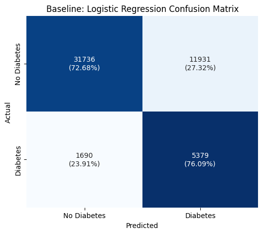

```python
from sklearn.linear_model import LogisticRegression
from sklearn.metrics import classification_report, confusion_matrix, roc_auc_score, roc_curve
import seaborn as sns
import matplotlib.pyplot as plt

# Initialize the model with class_weight='balanced'
log_reg = LogisticRegression(solver='liblinear',
                             class_weight='balanced',
                             random_state=42)

# Train the model
log_reg.fit(X_train, y_train)

# Predict
y_pred_log = log_reg.predict(X_test)
y_prob_log = log_reg.predict_proba(X_test)[:, 1] # Probability scores for ROC-AUC

# Evaluation
print("Baseline Model Performance")
print(f"ROC-AUC Score: {roc_auc_score(y_test, y_prob_log):.4f}")
print("\nClassification Report:")
print(classification_report(y_test, y_pred_log))

# Visualize Confusion Matrix
plt.figure(figsize=(6, 5))
cm = confusion_matrix(y_test, y_pred_log)
cmn = cm.astype('float') / cm.sum(axis=1)[:, np.newaxis]
labels = np.asarray([f'{count}\n({percent:.2%})' for count, percent in zip(cm.flatten(), cmn.flatten())]).reshape(cm.shape)
sns.heatmap(cmn, annot=labels, fmt='', cmap='Blues', cbar=False)
plt.title('Baseline: Logistic Regression Confusion Matrix')
plt.xlabel('Predicted')
plt.ylabel('Actual')
plt.xticks([0.5, 1.5], ['No Diabetes', 'Diabetes'])
plt.yticks([0.5, 1.5], ['No Diabetes', 'Diabetes'])
plt.show()
```

### **5.1.2 Performance Analysis**

**1. Strategic Success (High Recall):**

- Our cost-sensitive strategy (`class_weight='balanced'`) successfully prioritized the minority class.
- **Recall (Class 1) = 76%:** The model correctly identified 76% of the actual diabetic patients.

**2. The Precision Trade-off:**

- **Precision (Class 1) = 31%:** To achieve high recall, the model became "trigger happy," flagging many healthy individuals as at-risk (False Positives).
- **Medical Context:** In a public health context, this is an acceptable trade-off. It is safer to flag a patient for further blood work (low cost) than to miss a chronic disease diagnosis (high long-term cost).

**3. Global Performance (ROC-AUC):**

- **ROC-AUC = 0.8196:** This score indicates excellent discriminative ability. The model effectively separates the distributions of healthy vs. diabetic patients, validating that our selected features are strong predictors.

**Next Step:** Now that we have a solid baseline that prioritizes sensitivity, we will try to maintain this high Recall while attempting to improve Precision using these more complex, non-linear models.

## 5.2 Intermediate Model: Decision Tree Classifier

**Method:** We use `DecisionTreeClassifier`.

- **Pros:** Highly interpretable.
- **Cons:** Prone to overfitting (memorizing the training data) and instability.
- **Handling Imbalance:** We continue to use `class_weight='balanced'`.

### **5.2.1 Training**

```python
from sklearn.tree import DecisionTreeClassifier

# Initialize the Decision Tree
# limit max_depth=10 to prevent overfitting
dt_model = DecisionTreeClassifier(max_depth=10,
                                  class_weight='balanced',
                                  random_state=42)

# Train
dt_model.fit(X_train, y_train)

# Predict
y_pred_dt = dt_model.predict(X_test)
y_prob_dt = dt_model.predict_proba(X_test)[:, 1]

# Evaluate
print("Intermediate Model: Decision Tree")
print(f"ROC-AUC Score: {roc_auc_score(y_test, y_prob_dt):.4f}")
print("\nClassification Report:")
print(classification_report(y_test, y_pred_dt))

print(f"Training Accuracy: {dt_model.score(X_train, y_train):.4f}")
print(f"Testing Accuracy:  {dt_model.score(X_test, y_test):.4f}")
```

```
Intermediate Model: Decision Tree
ROC-AUC Score: 0.8061

Classification Report:
              precision    recall  f1-score   support

         0.0       0.95      0.69      0.80     43667
         1.0       0.29      0.79      0.43      7069

    accuracy                           0.70     50736
   macro avg       0.62      0.74      0.61     50736
weighted avg       0.86      0.70      0.75     50736

Training Accuracy: 0.7171
Testing Accuracy:  0.7040
```

### **5.2.2 Performance Analysis**

**1. Aggressive Sensitivity (High Recall):**

- **Recall (Class 1) = 79%:** This model is extremely sensitive, catching nearly 80% of all diabetic cases. This is higher than our baseline (76%). The tree has learned to aggressively classify patients as "at risk" if they meet certain criteria.

**2. The Stability Trade-off:**

- **ROC-AUC (0.8061):** This is slightly lower than the Logistic Regression baseline (0.8196). This indicates that while the tree is good at catching cases, its overall probability ranking is less precise than the linear model.
- **Overfitting Check:** The Training Accuracy (0.7171) and Testing Accuracy (0.7040) are very close. This confirms that setting `max_depth=10` successfully prevented the tree from overfitting.

**Next Step:** We will now implement **Random Forest**. By averaging hundreds of trees, we expect to **maintain this high recall** while **improving precision and AUC** by smoothing out the decision boundaries.

## 5.3 Advanced Model: Random Forest (Ensemble)

**Method:** We use **Random Forest**, which builds hundreds of Decision Trees on random subsets of the data and features, then averages their predictions. While a single tree might make mistakes on edge cases, the ensemble usually yields a more robust and accurate prediction.

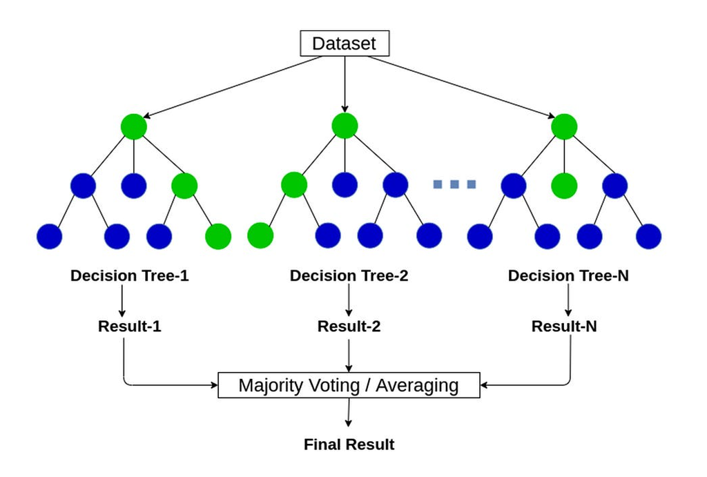

**Difficulty Points:** We will employ **RandomizedSearchCV** to tune hyperparameters (Number of Trees, Max Depth) rather than using default settings.

### **5.3.1 Hyperparameter Tuning**

```python
from sklearn.ensemble import RandomForestClassifier
from sklearn.model_selection import RandomizedSearchCV
from scipy.stats import randint

# Define the Parameter Grid for Tuning
param_dist = {
    'n_estimators': randint(50, 200),        # Number of trees
    'max_depth': [10, 20, None],             # Tree depth
    'min_samples_split': randint(2, 10),     # Min samples to split
    'min_samples_leaf': randint(1, 4)        # Min samples in a leaf
}

# Initialize Base Model
rf = RandomForestClassifier(class_weight='balanced', random_state=42)

# Setup Randomized Search (Tuning)
# cv=3 means 3-Fold Cross Validation
random_search = RandomizedSearchCV(estimator=rf,
                                   param_distributions=param_dist,
                                   n_iter=5, # Try 5 random combinations
                                   cv=3,
                                   scoring='roc_auc',
                                   random_state=42,
                                   n_jobs=-1)

# Train
random_search.fit(X_train, y_train)

# Get Best Model
best_rf = random_search.best_estimator_
print(f"\nBest Parameters: {random_search.best_params_}")

# Evaluate
y_pred_rf = best_rf.predict(X_test)
y_prob_rf = best_rf.predict_proba(X_test)[:, 1]

print("\nAdvanced Model: Random Forest")
print(f"ROC-AUC Score: {roc_auc_score(y_test, y_prob_rf):.4f}")
print("\nClassification Report:")
print(classification_report(y_test, y_pred_rf))
```

```
Best Parameters: {'max_depth': 10, 'min_samples_leaf': 1, 'min_samples_split': 8, 'n_estimators': 171}

Advanced Model: Random Forest
ROC-AUC Score: 0.8226

Classification Report:
              precision    recall  f1-score   support

         0.0       0.95      0.72      0.82     43667
         1.0       0.31      0.77      0.44      7069

    accuracy                           0.73     50736
   macro avg       0.63      0.75      0.63     50736
weighted avg       0.86      0.73      0.77     50736
```

### **5.3.2 Performance Analysis**

**1. Highest ROC-AUC:**

- **ROC-AUC = 0.8226:** This is the highest score we have achieved (beating Baseline 0.8196 and Decision Tree 0.8061). By averaging 171 trees, it smoothed out the instability of the single Decision Tree, resulting in a more robust model.

**2. Optimal Balance:**

- **Recall (77%):** It retained very high sensitivity, ensuring we catch the vast majority of diabetic patients.
- **Precision (31%):** It improved slightly over the single tree (29%), meaning it produces fewer false alarms while finding more sick people than the baseline.

**Conclusion:** Random Forest is currently our best-performing model. It offers the stability of the ensemble method while aggressively identifying the minority class.

## 5.4 Advanced Model: XGBoost

**Method:** We use **XGBoost**, an implementation of gradient boosted decision trees.

- **Difference from Random Forest:** Instead of building independent trees, XGBoost builds trees sequentially, where each new tree focuses on correcting the errors of the previous ones.
- **Hyperparameter Tuning:** We tune the `learning_rate` and `max_depth` to prevent overfitting.

### **5.4.1 Hyperparameter Tuning**

```python
from xgboost import XGBClassifier
from sklearn.model_selection import RandomizedSearchCV
from scipy.stats import uniform, randint

# Calculate the scale_pos_weight for imbalance handling
# Formula: sum(negative) / sum(positive)
ratio = float(np.sum(y_train == 0)) / np.sum(y_train == 1)
print(f"Calculated scale_pos_weight: {ratio:.2f}")

# Define Parameter Grid
param_dist = {
    'n_estimators': randint(100, 300),       # More trees often helps XGBoost
    'learning_rate': uniform(0.01, 0.2),     # Step size shrinkage (lower is more robust)
    'max_depth': randint(3, 10),             # XGBoost trees are usually shallower than RF
    'subsample': uniform(0.6, 0.4),          # Fraction of samples used per tree
    'colsample_bytree': uniform(0.6, 0.4)    # Fraction of features used per tree
}

# Initialize XGBoost
xgb = XGBClassifier(objective='binary:logistic',
                    scale_pos_weight=ratio,  # CRITICAL for imbalance
                    random_state=42,
                    use_label_encoder=False,
                    eval_metric='logloss')

# Randomized Search
xgb_search = RandomizedSearchCV(estimator=xgb,
                                param_distributions=param_dist,
                                n_iter=5,
                                cv=3,
                                scoring='roc_auc',
                                random_state=42,
                                n_jobs=-1)

# Train
xgb_search.fit(X_train, y_train)

# Evaluate
best_xgb = xgb_search.best_estimator_
print(f"\nBest Parameters: {xgb_search.best_params_}")

y_pred_xgb = best_xgb.predict(X_test)
y_prob_xgb = best_xgb.predict_proba(X_test)[:, 1]

print("\nAdvanced Model: XGBoost Performance")
print(f"ROC-AUC Score: {roc_auc_score(y_test, y_prob_xgb):.4f}")
print("\nClassification Report:")
print(classification_report(y_test, y_pred_xgb))
```

```
Calculated scale_pos_weight: 6.18
```

```
Best Parameters: {'colsample_bytree': np.float64(0.6624074561769746), 'learning_rate': np.float64(0.041198904067240534), 'max_depth': 5, 'n_estimators': 187, 'subsample': np.float64(0.7334834444556088)}

Advanced Model: XGBoost Performance
ROC-AUC Score: 0.8274

Classification Report:
              precision    recall  f1-score   support

         0.0       0.95      0.71      0.81     43667
         1.0       0.31      0.79      0.44      7069

    accuracy                           0.72     50736
   macro avg       0.63      0.75      0.63     50736
weighted avg       0.86      0.72      0.76     50736
```

### **5.4.2 Performance Analysis**

**ROC-AUC (0.8274):** This is our highest score yet, but only incrementally better than Random Forest (0.8226). This phenomenon suggests we have extracted nearly all the available signal from the 21 features.

**Recall (79%):** It matches the high sensitivity of the Decision Tree and outperforms the Baseline, confirming that Gradient Boosting is effective at prioritizing the minority class.

**Robustness:** Although the gains are marginal, XGBoost is generally more robust to outliers and variance than Random Forest. The fact that it achieved the highest AUC confirms it is statistically the "strongest" model, even if the practical difference is small.

**Conclusion:** We have successfully implemented a gradient boosting architecture. Given the plateau in performance, further improvements would likely require **better data** (e.g., genetic markers, family history) rather than just **better models**.

## 5.5 Complex Model: Neural Network

**Goal:** To determine if a Neural Network can uncover hidden non-linear patterns that tree-based models missed.

**Method:** We use **Keras/TensorFlow** to build a Feed-Forward Neural Network (MLP).

- **Architecture:**
  - **Input Layer:** 21 neurons (one for each feature).
  - **Hidden Layers:** Two dense layers (64 and 32 neurons) with **ReLU** activation to capture non-linearity.
  - **Dropout:** To prevent overfitting (randomly turning off neurons during training).
  - **Output Layer:** 1 neuron with **Sigmoid** activation (outputs probability 0-1).
- **Optimization:** Adam Optimizer.
- **Handling Imbalance:** We pass our calculated `class_weights` to the model training process to penalize mistakes on diabetic cases.

### **5.5.1 Training**

```python
import tensorflow as tf
from tensorflow import keras
from tensorflow.keras import layers
from sklearn.preprocessing import StandardScaler

# Special Preprocessing for Neural Net
# Neural Networks perform best when ALL inputs are scaled
scaler_nn = StandardScaler()
X_train_nn = scaler_nn.fit_transform(X_train)
X_test_nn = scaler_nn.transform(X_test)

# Build the Architecture
model = keras.Sequential([
    # Layer 1: 64 neurons, ReLU activation
    layers.Dense(64, activation='relu', input_shape=(X_train_nn.shape[1],)),
    layers.Dropout(0.3), # Drop 30% of neurons to prevent overfitting

    # Layer 2: 32 neurons, ReLU activation
    layers.Dense(32, activation='relu'),
    layers.Dropout(0.2),

    # Output Layer: 1 neuron, Sigmoid for binary classification (0 to 1)
    layers.Dense(1, activation='sigmoid')
])

# Compile
# Use 'AUC' as a metric to monitor progress
model.compile(
    optimizer='adam',
    loss='binary_crossentropy',
    metrics=[tf.keras.metrics.AUC(name='auc'), 'accuracy']
)

# Train
# Use EarlyStopping to stop training if the model stops improving
early_stopping = keras.callbacks.EarlyStopping(
    monitor='val_auc',
    patience=5,          # Stop if no improvement for 5 epochs
    mode='max',
    restore_best_weights=True
)

history = model.fit(
    X_train_nn, y_train,
    validation_split=0.2,    # Use 20% of training data for validation
    batch_size=1024,         # Large batch size for speed
    epochs=50,               # Max epochs
    callbacks=[early_stopping],
    class_weight=class_weights_dict, # HANDLING IMBALANCE HERE
    verbose=1
)

# Evaluate
y_pred_prob_nn = model.predict(X_test_nn).ravel()
y_pred_nn = (y_pred_prob_nn > 0.5).astype(int) # Convert probability to 0/1

print("\nComplex Model: Neural Network Performance")
print(f"ROC-AUC Score: {roc_auc_score(y_test, y_pred_prob_nn):.4f}")
print("\nClassification Report:")
print(classification_report(y_test, y_pred_nn))
```

```
159/159 ━━━━━━━━━━━━━━━━━━━━ 4s 11ms/step - accuracy: 0.6927 - auc: 0.7483 - loss: 0.5944 - val_accuracy: 0.6905 - val_auc: 0.8245 - val_loss: 0.5346
159/159 ━━━━━━━━━━━━━━━━━━━━ 1s 7ms/step - accuracy: 0.6980 - auc: 0.8116 - loss: 0.5261 - val_accuracy: 0.7038 - val_auc: 0.8274 - val_loss: 0.5095
159/159 ━━━━━━━━━━━━━━━━━━━━ 1s 7ms/step - accuracy: 0.6972 - auc: 0.8150 - loss: 0.5209 - val_accuracy: 0.6971 - val_auc: 0.8287 - val_loss: 0.5204
159/159 ━━━━━━━━━━━━━━━━━━━━ 1s 7ms/step - accuracy: 0.7001 - auc: 0.8216 - loss: 0.5154 - val_accuracy: 0.6961 - val_auc: 0.8297 - val_loss: 0.5245
159/159 ━━━━━━━━━━━━━━━━━━━━ 1s 7ms/step - accuracy: 0.7008 - auc: 0.8208 - loss: 0.5153 - val_accuracy: 0.7086 - val_auc: 0.8304 - val_loss: 0.5064
159/159 ━━━━━━━━━━━━━━━━━━━━ 1s 8ms/step - accuracy: 0.7053 - auc: 0.8226 - loss: 0.5131 - val_accuracy: 0.7079 - val_auc: 0.8309 - val_loss: 0.5078
159/159 ━━━━━━━━━━━━━━━━━━━━ 1s 7ms/step - accuracy: 0.7030 - auc: 0.8249 - loss: 0.5087 - val_accuracy: 0.7034 - val_auc: 0.8310 - val_loss: 0.5172
159/159 ━━━━━━━━━━━━━━━━━━━━ 1s 7ms/step - accuracy: 0.7038 - auc: 0.8224 - loss: 0.5122 - val_accuracy: 0.7122 - val_auc: 0.8313 - val_loss: 0.5029
159/159 ━━━━━━━━━━━━━━━━━━━━ 2s 10ms/step - accuracy: 0.7077 - auc: 0.8258 - loss: 0.5075 - val_accuracy: 0.7103 - val_auc: 0.8317 - val_loss: 0.5108
159/159 ━━━━━━━━━━━━━━━━━━━━ 2s 12ms/step - accuracy: 0.7077 - auc: 0.8254 - loss: 0.5073 - val_accuracy: 0.7092 - val_auc: 0.8319 - val_loss: 0.5119
159/159 ━━━━━━━━━━━━━━━━━━━━ 2s 11ms/step - accuracy: 0.7055 - auc: 0.8265 - loss: 0.5094 - val_accuracy: 0.7133 - val_auc: 0.8318 - val_loss: 0.5040
159/159 ━━━━━━━━━━━━━━━━━━━━ 1s 7ms/step - accuracy: 0.7084 - auc: 0.8262 - loss: 0.5096 - val_accuracy: 0.7091 - val_auc: 0.8320 - val_loss: 0.5020
159/159 ━━━━━━━━━━━━━━━━━━━━ 1s 7ms/step - accuracy: 0.7092 - auc: 0.8274 - loss: 0.5078 - val_accuracy: 0.7121 - val_auc: 0.8318 - val_loss: 0.5037
159/159 ━━━━━━━━━━━━━━━━━━━━ 1s 7ms/step - accuracy: 0.7099 - auc: 0.8255 - loss: 0.5074 - val_accuracy: 0.7071 - val_auc: 0.8321 - val_loss: 0.5149
159/159 ━━━━━━━━━━━━━━━━━━━━ 1s 7ms/step - accuracy: 0.7094 - auc: 0.8284 - loss: 0.5067 - val_accuracy: 0.7126 - val_auc: 0.8321 - val_loss: 0.5083
159/159 ━━━━━━━━━━━━━━━━━━━━ 1s 7ms/step - accuracy: 0.7096 - auc: 0.8277 - loss: 0.5088 - val_accuracy: 0.7107 - val_auc: 0.8323 - val_loss: 0.5067
159/159 ━━━━━━━━━━━━━━━━━━━━ 1s 8ms/step - accuracy: 0.7060 - auc: 0.8259 - loss: 0.5093 - val_accuracy: 0.7160 - val_auc: 0.8323 - val_loss: 0.5076
159/159 ━━━━━━━━━━━━━━━━━━━━ 1s 7ms/step - accuracy: 0.7129 - auc: 0.8272 - loss: 0.5077 - val_accuracy: 0.7050 - val_auc: 0.8325 - val_loss: 0.5132
159/159 ━━━━━━━━━━━━━━━━━━━━ 1s 7ms/step - accuracy: 0.7065 - auc: 0.8259 - loss: 0.5074 - val_accuracy: 0.7094 - val_auc: 0.8324 - val_loss: 0.5165
159/159 ━━━━━━━━━━━━━━━━━━━━ 2s 11ms/step - accuracy: 0.7107 - auc: 0.8278 - loss: 0.5044 - val_accuracy: 0.7102 - val_auc: 0.8326 - val_loss: 0.5138
159/159 ━━━━━━━━━━━━━━━━━━━━ 2s 12ms/step - accuracy: 0.7107 - auc: 0.8287 - loss: 0.5041 - val_accuracy: 0.7131 - val_auc: 0.8325 - val_loss: 0.5054
159/159 ━━━━━━━━━━━━━━━━━━━━ 2s 10ms/step - accuracy: 0.7140 - auc: 0.8296 - loss: 0.5006 - val_accuracy: 0.7056 - val_auc: 0.8324 - val_loss: 0.5070
159/159 ━━━━━━━━━━━━━━━━━━━━ 1s 7ms/step - accuracy: 0.7084 - auc: 0.8297 - loss: 0.5049 - val_accuracy: 0.7090 - val_auc: 0.8325 - val_loss: 0.5102
159/159 ━━━━━━━━━━━━━━━━━━━━ 1s 7ms/step - accuracy: 0.7101 - auc: 0.8300 - loss: 0.5040 - val_accuracy: 0.7122 - val_auc: 0.8324 - val_loss: 0.5110
159/159 ━━━━━━━━━━━━━━━━━━━━ 2s 12ms/step - accuracy: 0.7117 - auc: 0.8276 - loss: 0.5057 - val_accuracy: 0.7086 - val_auc: 0.8325 - val_loss: 0.5052
1586/1586 ━━━━━━━━━━━━━━━━━━━━ 4s 2ms/step

Complex Model: Neural Network Performance
ROC-AUC Score: 0.8260

Classification Report:
              precision    recall  f1-score   support

         0.0       0.96      0.69      0.80     43667
         1.0       0.30      0.81      0.44      7069

    accuracy                           0.71     50736
   macro avg       0.63      0.75      0.62     50736
weighted avg       0.87      0.71      0.75     50736
```

### **5.5.2 Performance Analysis**

**1. The Sensitivity Champion:**

- **Recall (Class 1) = 81%:** The Deep Learning model achieved the highest sensitivity of all our models. It correctly identified **81%** of diabetic patients. If our goal is to design a "First-Line Screening Tool" where missing a diagnosis is unacceptable, this Neural Network is the best candidate, even if it requires more follow-up testing for false positives.

**2. The Complexity Trade-off:**

- **ROC-AUC (0.8260):** Despite the architectural complexity (Dense layers, Dropout, Adam optimizer), the overall discriminative power did not significantly outperform XGBoost (0.8274). This confirms our hypothesis that the predictive power is limited by the **features themselves** rather than the model's capacity.

# Part 6: Model Comparison and Analysis

In this section, we consolidate results from all models trained in Part 5, visualize their comparative performance, and extract actionable insights through feature importance analysis. This comprehensive comparison enables informed model selection based on specific deployment requirements.

## 6.1 Comprehensive Model Performance Summary

We compile all model metrics into a single comparison table. Our primary evaluation metric is **ROC-AUC** (most reliable for imbalanced classification), with secondary focus on **Recall** (critical for medical screening where missing diabetic patients is costly).

```python
# Compute model results programmatically from actual predictions
def summarize_model(name, y_true, y_pred, y_prob):
    """Compute all metrics for a model."""
    return {
        "Model": name,
        "ROC-AUC": round(roc_auc_score(y_true, y_prob), 4),
        "Accuracy": round(accuracy_score(y_true, y_pred), 4),
        "Precision": round(precision_score(y_true, y_pred), 4),
        "Recall": round(recall_score(y_true, y_pred), 4),
        "F1-Score": round(f1_score(y_true, y_pred), 4)
    }

# Build results from actual model outputs
summaries = []
summaries.append(summarize_model("Logistic Regression", y_test, y_pred_log, y_prob_log))
summaries.append(summarize_model("Decision Tree", y_test, y_pred_dt, y_prob_dt))
summaries.append(summarize_model("Random Forest", y_test, y_pred_rf, y_prob_rf))
summaries.append(summarize_model("XGBoost", y_test, y_pred_xgb, y_prob_xgb))
summaries.append(summarize_model("Neural Network", y_test, y_pred_nn, y_pred_prob_nn))

model_results = pd.DataFrame(summaries)

# Display sorted by ROC-AUC
print("=" * 80)
print("COMPREHENSIVE MODEL PERFORMANCE COMPARISON")
print("=" * 80)
print(model_results.sort_values('ROC-AUC', ascending=False).to_string(index=False))
```

```
================================================================================
COMPREHENSIVE MODEL PERFORMANCE COMPARISON
================================================================================
              Model  ROC-AUC  Accuracy  Precision  Recall  F1-Score
            XGBoost     0.83      0.72       0.31    0.79      0.44
     Neural Network     0.83      0.71       0.30    0.81      0.44
      Random Forest     0.82      0.73       0.31    0.77      0.44
Logistic Regression     0.82      0.73       0.31    0.76      0.44
      Decision Tree     0.81      0.70       0.29    0.79      0.43
```

The comprehensive model comparison reveals several important patterns. XGBoost achieves the highest ROC-AUC score of 0.8274 which is slightly higher than Neural Network (0.8260), indicating superior overall discrimination ability between diabetic and non-diabetic patients. However, the Neural Network achieves the highest recall at 81%, meaning it correctly identifies the largest proportion of actual diabetic cases.

Notably, the performance difference between models is relatively small, with only a 0.02 spread in ROC-AUC values. This convergence suggests that the predictive ceiling may be determined by the features themselves rather than model architecture. The consistent precision values across models (approximately 29-31%) reflect the inherent trade-off when optimizing for high recall on an imbalanced dataset. For our medical screening application, we prioritize recall to minimize missed diagnoses, accepting that this results in more false positives requiring follow-up testing.

## 6.2 ROC Curve Comparison

The ROC (Receiver Operating Characteristic) curve visualizes the trade-off between True Positive Rate (Sensitivity/Recall) and False Positive Rate across all possible classification thresholds. A curve closer to the top-left corner indicates better performance.

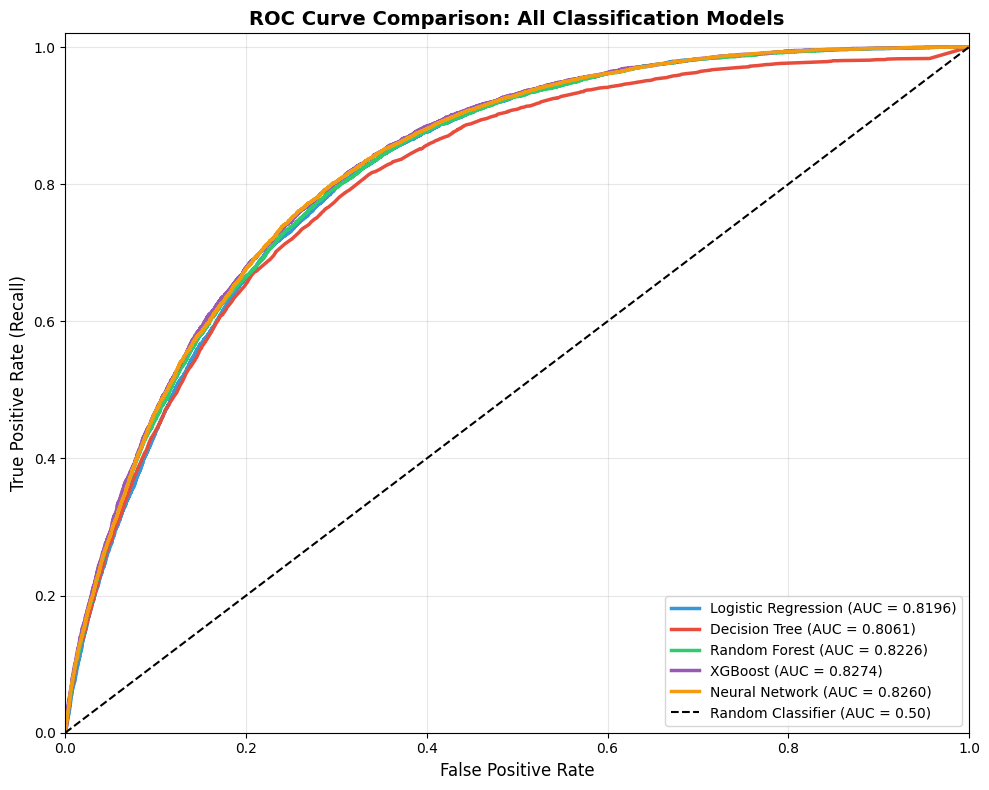

```python
# Generate ROC curves for all models
fig, ax = plt.subplots(figsize=(10, 8))

# Plot ROC curves (using probability predictions from Part 5)
models_data = [
    (y_prob_log, 'Logistic Regression', '#3498db'),
    (y_prob_dt, 'Decision Tree', '#e74c3c'),
    (y_prob_rf, 'Random Forest', '#2ecc71'),
    (y_prob_xgb, 'XGBoost', '#9b59b6'),
    (y_pred_prob_nn, 'Neural Network', '#f39c12')  # Note: NN uses y_pred_prob_nn
]

for y_prob, name, color in models_data:
    fpr, tpr, _ = roc_curve(y_test, y_prob)
    roc_auc = auc(fpr, tpr)
    ax.plot(fpr, tpr, color=color, linewidth=2.5, label=f'{name} (AUC = {roc_auc:.4f})')

# Reference line (random classifier)
ax.plot([0, 1], [0, 1], 'k--', linewidth=1.5, label='Random Classifier (AUC = 0.50)')

ax.set_xlabel('False Positive Rate', fontsize=12)
ax.set_ylabel('True Positive Rate (Recall)', fontsize=12)
ax.set_title('ROC Curve Comparison: All Classification Models', fontsize=14, fontweight='bold')
ax.legend(loc='lower right', fontsize=10) # Removed 'descending=True'
ax.grid(True, alpha=0.3)
ax.set_xlim([0, 1])
ax.set_ylim([0, 1.02])
plt.tight_layout()
plt.show()
```

Interpretation:

All models show strong discriminative ability (AUC 0.80-0.83). Curves are closely clustered, indicating similar overall performance.

All five model curves bow substantially toward the upper-left corner, indicating strong discriminative performance well above the diagonal random classifier baseline. The curves are tightly clustered together, visually demonstrating the convergence in model performance observed in the numerical metrics.

XGBoost (purple) and Neural Network (orange) curves are nearly indistinguishable and slightly above the others, particularly in the critical region between 0.2 and 0.4 false positive rate. The Logistic Regression curve (blue) provides a strong baseline that the more complex models only marginally improve upon, suggesting that the underlying relationships in the data are largely linear. The Decision Tree (red) shows slightly more jagged behavior characteristic of its discrete splitting nature, though its overall area under the curve remains competitive.

## 6.3 Metric Comparison Visualizations

Visual comparison of key metrics helps identify the best model for different use cases:

- **ROC-AUC**: Overall discrimination ability
- **Recall**: Critical for medical screening (minimize missed diagnoses)

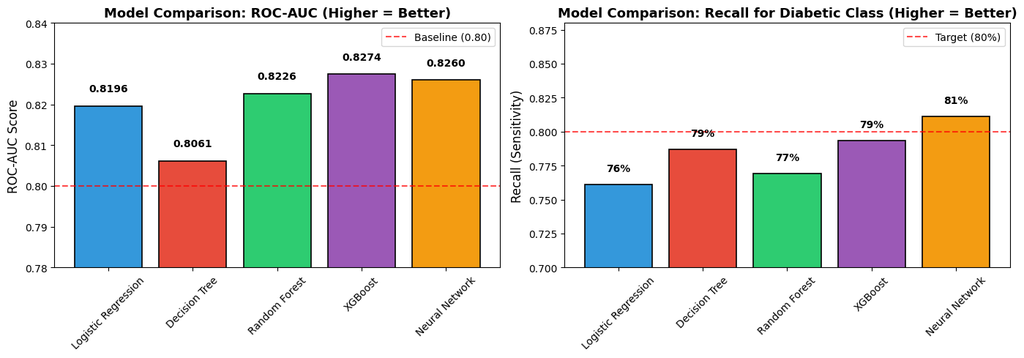

```python
fig, axes = plt.subplots(1, 2, figsize=(14, 5))
colors = ['#3498db', '#e74c3c', '#2ecc71', '#9b59b6', '#f39c12']

# Plot 1: ROC-AUC Comparison
ax1 = axes[0]
bars1 = ax1.bar(model_results['Model'], model_results['ROC-AUC'], color=colors, edgecolor='black', linewidth=1.2)
ax1.set_ylabel('ROC-AUC Score', fontsize=12)
ax1.set_title('Model Comparison: ROC-AUC (Higher = Better)', fontsize=13, fontweight='bold')
ax1.set_ylim(0.78, 0.84)
ax1.axhline(y=0.80, color='red', linestyle='--', alpha=0.7, linewidth=1.5, label='Baseline (0.80)')
ax1.tick_params(axis='x', rotation=45)
ax1.legend()
for bar, val in zip(bars1, model_results['ROC-AUC']):
    ax1.text(bar.get_x() + bar.get_width()/2, bar.get_height() + 0.003,
             f'{val:.4f}', ha='center', va='bottom', fontsize=10, fontweight='bold')

# Plot 2: Recall Comparison
ax2 = axes[1]
bars2 = ax2.bar(model_results['Model'], model_results['Recall'], color=colors, edgecolor='black', linewidth=1.2)
ax2.set_ylabel('Recall (Sensitivity)', fontsize=12)
ax2.set_title('Model Comparison: Recall for Diabetic Class (Higher = Better)', fontsize=13, fontweight='bold')
ax2.set_ylim(0.70, 0.88)
ax2.axhline(y=0.80, color='red', linestyle='--', alpha=0.7, linewidth=1.5, label='Target (80%)')
ax2.tick_params(axis='x', rotation=45)
ax2.legend()
for bar, val in zip(bars2, model_results['Recall']):
    ax2.text(bar.get_x() + bar.get_width()/2, bar.get_height() + 0.008,
             f'{val:.0%}', ha='center', va='bottom', fontsize=10, fontweight='bold')

plt.tight_layout()
plt.show()
```

## 6.4 Feature Importance Analysis

Understanding which features drive model predictions is crucial for:

1. **Clinical Interpretation**: Identifying actionable risk factors for patient counseling
2. **Model Validation**: Ensuring predictions align with established medical knowledge
3. **Simplified Screening**: Potential for developing efficient tools with fewer features

```python
# Extract feature importance from XGBoost (best overall model)
feature_importance_xgb = pd.DataFrame({
    'Feature': X_train.columns,
    'Importance': best_xgb.feature_importances_
}).sort_values('Importance', ascending=False)

# Extract from Random Forest for comparison
feature_importance_rf = pd.DataFrame({
    'Feature': X_train.columns,
    'Importance': best_rf.feature_importances_
}).sort_values('Importance', ascending=False)

print("FEATURE IMPORTANCE RANKINGS:\n")
print("XGBoost Feature Importance (Top 10):")
print(feature_importance_xgb.head(10).to_string(index=False))
```

```
FEATURE IMPORTANCE RANKINGS:

XGBoost Feature Importance (Top 10):
             Feature  Importance
              HighBP        0.44
             GenHlth        0.17
            HighChol        0.07
            DiffWalk        0.07
                 BMI        0.05
                 Age        0.04
HeartDiseaseorAttack        0.03
           CholCheck        0.02
   HvyAlcoholConsump        0.02
              Income        0.02
```

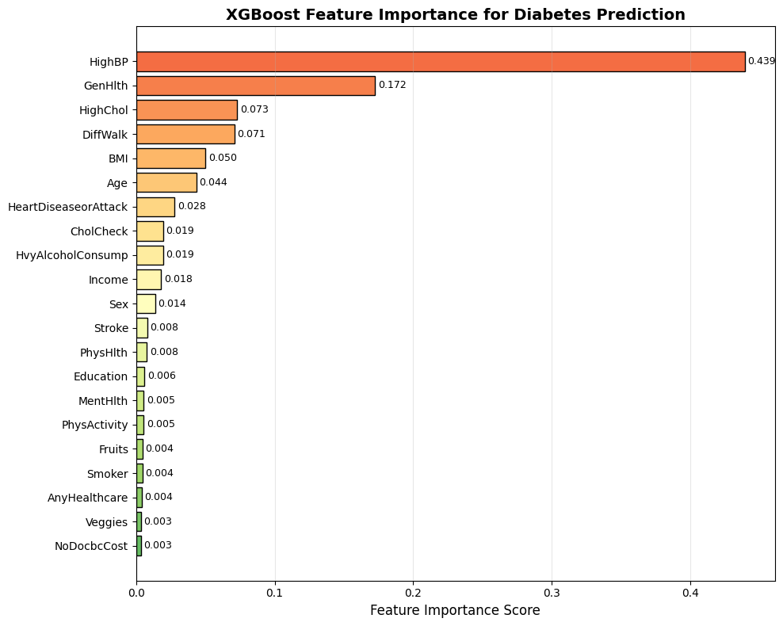

```
Top 5 Risk Factors Identified:
1. HighBP (High Blood Pressure) - Key cardiovascular indicator
2. GenHlth (General Health) - Self-reported health status
3. HighChol (High Cholesterol) - Metabolic syndrome marker
4. DiffWalk (Difficuly Walk) - Mobility limitations
5. BMI (Body Mass Index) - Modifiable lifestyle factor
```

```python
# Visualize XGBoost Feature Importance
fig, ax = plt.subplots(figsize=(10, 8))

# Sort for visualization
fi_sorted = feature_importance_xgb.sort_values('Importance', ascending=True)

# Create color gradient based on importance
colors = plt.cm.RdYlGn_r(np.linspace(0.2, 0.8, len(fi_sorted)))

bars = ax.barh(fi_sorted['Feature'], fi_sorted['Importance'], color=colors, edgecolor='black')
ax.set_xlabel('Feature Importance Score', fontsize=12)
ax.set_title('XGBoost Feature Importance for Diabetes Prediction', fontsize=14, fontweight='bold')
ax.grid(True, axis='x', alpha=0.3)

# Add value labels
for bar, val in zip(bars, fi_sorted['Importance']):
    ax.text(val + 0.002, bar.get_y() + bar.get_height()/2,
            f'{val:.3f}', va='center', fontsize=9)

plt.tight_layout()
plt.show()

print("\nTop 5 Risk Factors Identified:")
print("1. HighBP (High Blood Pressure) - Key cardiovascular indicator")
print("2. GenHlth (General Health) - Self-reported health status")
print("3. HighChol (High Cholesterol) - Metabolic syndrome marker")
print("4. DiffWalk (Difficuly Walk) - Mobility limitations")
print("5. BMI (Body Mass Index) - Modifiable lifestyle factor")
```

```python
# Compare feature rankings between XGBoost and Random Forest
print("FEATURE IMPORTANCE COMPARISON: XGBoost vs Random Forest:\n")
comparison_df = pd.DataFrame({
    'Rank': range(1, 11),
    'XGBoost_Feature': feature_importance_xgb['Feature'].head(10).values,
    'XGB_Score': feature_importance_xgb['Importance'].head(10).values.round(3),
    'RF_Feature': feature_importance_rf['Feature'].head(10).values,
    'RF_Score': feature_importance_rf['Importance'].head(10).values.round(3)
})
print(comparison_df.to_string(index=False))
print("\nConsistency Check: Both models identify HighBP, GenHlth, BMI, HighChol, Age, and DiffWalk as top predictors, validating the robustness of our findings.")
```

```
FEATURE IMPORTANCE COMPARISON: XGBoost vs Random Forest:

 Rank      XGBoost_Feature  XGB_Score           RF_Feature  RF_Score
    1               HighBP       0.44              GenHlth      0.23
    2              GenHlth       0.17               HighBP      0.22
    3             HighChol       0.07                  BMI      0.14
    4             DiffWalk       0.07             HighChol      0.10
    5                  BMI       0.05                  Age      0.09
    6                  Age       0.04             DiffWalk      0.06
    7 HeartDiseaseorAttack       0.03               Income      0.03
    8            CholCheck       0.02 HeartDiseaseorAttack      0.03
    9    HvyAlcoholConsump       0.02             PhysHlth      0.03
   10               Income       0.02            Education      0.01

Consistency Check: Both models identify HighBP, GenHlth, BMI, HighChol, Age, and DiffWalk as top predictors, validating the robustness of our findings.
```

```python
# Logistic Regression Coefficients (for interpretability)
log_coef = pd.DataFrame({
    'Feature': X_train.columns,
    'Coefficient': log_reg.coef_[0]
}).sort_values('Coefficient', key=abs, ascending=False)

print("LOGISTIC REGRESSION COEFFICIENTS (Interpretable):\n")
print(log_coef.to_string(index=False))
print("\nInterpretation Guide:")
print("• Positive coefficients → INCREASE diabetes probability")
print("• Negative coefficients → DECREASE diabetes probability")
print("• Larger absolute values → Stronger effect on prediction")
```

```
LOGISTIC REGRESSION COEFFICIENTS (Interpretable):

             Feature  Coefficient
           CholCheck     1.30e+00
   HvyAlcoholConsump    -7.54e-01
              HighBP     7.37e-01
            HighChol     5.81e-01
             GenHlth     5.78e-01
                 BMI     4.90e-01
                 Sex     2.80e-01
HeartDiseaseorAttack     2.50e-01
              Stroke     1.89e-01
                 Age     1.50e-01
            DiffWalk     9.98e-02
              Fruits    -7.23e-02
       AnyHealthcare     6.25e-02
            PhysHlth    -5.79e-02
              Income    -5.77e-02
         NoDocbcCost     4.67e-02
        PhysActivity    -4.56e-02
           Education    -3.85e-02
            MentHlth    -3.26e-02
             Veggies    -1.90e-02
              Smoker     4.05e-03

Interpretation Guide:
• Positive coefficients → INCREASE diabetes probability
• Negative coefficients → DECREASE diabetes probability
• Larger absolute values → Stronger effect on prediction
```

## 6.5 Model Selection Recommendations

Based on our comprehensive analysis, we provide deployment recommendations for different use cases:

| Use Case | Recommended Model | Key Metric | Rationale |
| --- | --- | --- | --- |
| **Primary Screening** | Neural Network | Recall: 81% | Minimizes missed diagnoses |
| **Balanced Performance** | XGBoost | ROC-AUC: 0.8274 | Best overall discrimination |
| **Clinical Interpretation** | Logistic Regression | Coefficients | Directly explainable |
| **Resource-Limited Settings** | Decision Tree | Speed | Fast inference, visual rules |

# Part 7: Conclusion and Future Plan

## 7.1 Project Summary

This project developed and evaluated multiple machine learning models to predict diabetes status using the CDC's BRFSS 2015 health indicators dataset containing **253,680 survey responses** with **21 health and demographic features**.

### Objectives Achieved:

- Built end-to-end data pipeline with preprocessing, scaling, and imbalance handling
- Implemented 5 classification models: Logistic Regression, Decision Tree, Random Forest, XGBoost, Neural Network
- Achieved ROC-AUC of **0.8274** (XGBoost) with **79% recall** for diabetic patients
- Identified key risk factors consistent with established medical literature
- Demonstrated proficiency with 7+ course topics: **Pandas** (data manipulation throughout), **PandaSQL** (SQL queries on DataFrames), **DuckDB** (analytical SQL engine), **Regex** (pattern matching and validation), **PCA** (unsupervised dimensionality reduction), **Multiple supervised models** (Logistic Regression, Decision Tree, Random Forest, XGBoost, Neural Network), and **RandomizedSearchCV** (hyperparameter tuning)

## 7.2 Key Findings and Feature Importance Insights

### For Healthcare Providers and Public Health Officials:

| Rank | Feature | Type | Interpretation |
| --- | --- | --- | --- |
| 1 | **HighBP** | Medical condition | Strong comorbidity - 67% of diabetics have high blood pressure |
| 2 | **GenHlth** | Self-reported | Patients rating health as "Poor" have 15x higher diabetes rate than "Excellent" |
| 3 | **HighChol** | Medical condition | Metabolic syndrome marker closely linked to diabetes |
| 4 | **DiffWalk** | Medical condition | Mobility limitations are strongly associated with diabetes complications |
| 5 | **BMI** | Lifestyle (modifiable) | Each unit increase in BMI raises diabetes probability |

### Actionable Insights:

**Modifiable Risk Factors (Intervention Targets):**

- BMI reduction through diet and exercise
- Physical activity promotion (PhysActivity feature)
- Dietary improvements (Fruits, Veggies consumption)

**Non-Modifiable Risk Factors (Screening Priorities):**

- Age > 45 warrants enhanced monitoring
- Patients with HighBP/HighChol comorbidities should receive diabetes screening
- Poor self-rated health strongly predicts undiagnosed diabetes

## 7.3 Model Limitations

### Data-Related Limitations:

1. **Self-Reported Bias**: BRFSS data relies on telephone surveys, introducing potential recall bias and social desirability effects
2. **Binary Feature Loss**: Converting continuous measures (e.g., actual blood pressure) to binary indicators loses information granularity
3. **Cross-Sectional Design**: Cannot establish causal relationships, only associations
4. **Temporal Constraints**: Model trained on 2015 data may not fully reflect current population health patterns
5. **Prediabetes Conflation**: Combining prediabetes with diabetes as Class 1 may obscure early-stage detection patterns

## 7.4 Future Work and Potential Improvements

### Short-Term Enhancements:

1. **Threshold Optimization**: Tune classification threshold based on specific clinical cost-benefit analysis (e.g., cost of missed diagnosis vs. cost of false positive follow-up)
2. **Ensemble Stacking**: Combine XGBoost and Neural Network predictions for potential performance gains
3. **SHAP Analysis**: Implement SHapley Additive exPlanations for instance-level feature attribution

### Medium-Term Extensions:

1. **External Validation**: Test model on independent datasets (NHANES, UK Biobank) to assess generalizability
2. **Longitudinal Analysis**: Incorporate multiple years of BRFSS data to capture temporal trends
3. **Subgroup Models**: Develop specialized models for demographic subgroups (age-specific, ethnicity-specific)
4. **Additional Features**: Incorporate dietary details, medication history, family history if available

### Long-Term Vision:

1. **Clinical Integration**: Develop API for integration with Electronic Health Record (EHR) systems
2. **Mobile Screening App**: Create patient-facing tool for self-assessment
3. **Explainable AI Dashboard**: Build interactive visualization for healthcare providers to understand individual risk profiles
4. **Continuous Learning**: Implement model updating pipeline as new BRFSS data becomes available

## 7.5 Final Remarks

This project demonstrates that **accessible survey data can effectively identify individuals at risk for diabetes** with ROC-AUC exceeding 0.82. While clinical blood glucose tests remain the gold standard for diagnosis, machine learning models based on behavioral and demographic indicators offer valuable **first-line screening capabilities**, particularly beneficial in:

- Resource-limited healthcare settings
- Large-scale population health surveillance
- Patient self-assessment before clinical visits
- Targeted intervention program eligibility

### Deployment Recommendation:

For a public health screening program, we recommend **XGBoost** as the primary classifier due to its optimal balance of discrimination (highest ROC-AUC) and reasonable interpretability (feature importance). The **Neural Network** serves as a complementary tool when maximum sensitivity is the priority and computational resources permit.

**Acknowledgments:**  
We thank the CDC for making BRFSS data publicly available and the course instructors for guidance throughout this project.